# Der Effekt von Earnings-Conference Calls am Aktienmarkt

# Motivation

Earnings Conference Calls sind zentrale Informationsereignisse in Finanzmärkten. Hier kommuniziert das Management direkt mit Investoren und Analysten über die aktuelle Geschäftslage und Zukunftsaussichten. Die finanzwirtschaftliche Forschung zeigt, dass diese Calls erhebliche Kursbewegungen auslösen können - doch die zugrundeliegenden Mechanismen sind noch nicht vollständig verstanden.

Während traditionelle Finanztheorie von effizienten Märkten ausgeht, die alle verfügbaren Informationen sofort verarbeiten, zeigen empirische Studien, dass die Art der Kommunikation und das Sentiment der Aussagen eigenständige Erklärungskraft für Aktienkursreaktionen besitzen. Diese Erkenntnisse haben direkte praktische Relevanz: Banken nutzen Sentiment-Analysen für algorithmische Handelsstrategien, Hedge Fonds entwickeln systematische Ansätze zur Textauswertung, und Asset Manager integrieren qualitative Informationen in ihre Bewertungsmodelle.

In diesem Projekt kombinieren Sie Event Studies - eine etablierte Methode der empirischen Finanzforschung zur Messung von Informationseffekten - mit modernen Large Language Models zur systematischen Textanalyse. Sie untersuchen, ob und wie sich qualitative Aussagen des Managements in quantifizierbaren Marktreaktionen niederschlagen, und lernen dabei sowohl die methodischen Grundlagen der Kausalitätsidentifikation als auch den praktischen Umgang mit KI-gestützten Finanzanalysen kennen.

# Event-Study-Methodik und theoretische Diskussion

1. Lesen Sie das Kapitel [“Event Studies” in Huntington-Klein (2021)](https://theeffectbook.net/ch-EventStudies.html) und beantworten Sie die folgenden Fragen dazu:

Kann eine Eventstudie helfen, den kausalen Effekt eines Earnings Conference Calls auf die Aktienrendite eines Unternehmens zu identifizieren? Gehen Sie bei der Beantwortung dieser Frage insbesondere auf die nachfolgenden Punkte ein:

- Welche Art von Variation nutzt eine Eventstudie zur Identifikation des Effekts?
- Welche Voraussetzung(en) müssen erfüllt sein, damit die Eventstudie eine gültige Kausalschätzung liefert?
  - Was bedeutet das “Joint-Test Problem” in diesem Kontext?

*Antwort:*

*Kann eine Eventstudie helfen, den kausalen Effekt eines Earnings Conference Calls auf die Aktienrendite zu identifizieren?:*

Earnings Conference Calls (ECCs) sind zentrale Informationsereignisse in den Finanzmärkten, bei denen das Management eines Unternehmens direkt mit Investoren und Analysten über Geschäftszahlen, Strategien und Zukunftsaussichten kommuniziert. Da sich neue Informationen potenziell unmittelbar auf Aktienkurse auswirken, stellt sich die Frage, ob und wie sich der Einfluss solcher Calls empirisch messen lässt, insbesondere im Hinblick auf kausale Effekte auf die Aktienrenditen. Die Event-Study-Methodik ist eine etablierte Herangehensweise zur Messung solcher Informationseffekte und kann grundsätzlich auch im Kontext von ECCs eingesetzt werden. Damit sie jedoch belastbare kausale Aussagen erlaubt, müssen bestimmte methodische Voraussetzungen erfüllt sein.

*Art der Variation: Zeitlicher Informationsschock:*

Eine Eventstudie nutzt die zeitliche Variation rund um ein klar definiertes Ereignis, hier der Zeitpunkt des Earnings Conference Calls, zur Identifikation von Effekten auf ökonomische Zielgrößen wie Aktienrenditen. Das grundlegende Prinzip basiert auf einem Vorher-Nachher-Vergleich: Im sogenannten „Pre-Event-Window“ wird anhand eines geeigneten Modells (z.B. Marktmodell oder CAPM) die erwartete Rendite geschätzt, also jene, die auch ohne das Ereignis eingetreten wäre. Im Anschluss werden im „Event-Window“ die tatsächlich realisierten Renditen beobachtet. Die Differenz zwischen beiden, die sogenannten Abnormal Returns (ARs), wird dann als potenzieller Effekt des Ereignisses interpretiert.

Entscheidend ist dabei, dass die Veränderung des Kurses unmittelbar auf neue Informationen zurückgeführt wird, die durch den ECC bekannt wurden. In diesem Sinne fungiert der Zeitpunkt des Calls als ein exogener Schock im Informationsfluss des Marktes.

*Voraussetzungen für eine gültige Kausalschätzung:*

Damit eine Eventstudie tatsächlich eine kausale Interpretation erlaubt, müssen mehrere methodische Voraussetzungen erfüllt sein.

Erstens muss gewährleistet sein, dass keine anderen marktbewegenden Ereignisse im unmittelbaren Umfeld des Conference Calls stattfinden. Solche konkurrierenden Informationen, wie etwa Gewinnwarnungen, Fusionsankündigungen oder makroökonomische Schocks, würden das Ergebnis verzerren, da sich die beobachteten Kursveränderungen dann nicht eindeutig auf den ECC zurückführen ließen. Die Isolierung des Ereignisses ist daher entscheidend.

Zweitens ist ein stabiles und korrekt spezifiziertes Modell zur Schätzung der erwarteten Rendite erforderlich. Nur wenn das gewählte Modell (etwa das Marktmodell oder ein multifaktorielles Modell) die Normalrendite realistisch abbildet, lässt sich die Differenz zur tatsächlichen Rendite sinnvoll interpretieren. Ein schlechtes Modell kann zu einer falschen Attribution von Kurseffekten führen.

Drittens setzt die Methode zumindest eine abgeschwächte Form von Markteffizienz voraus: Neue Informationen aus dem ECC müssen zeitnah in die Preise eingepreist werden. Nur unter dieser Annahme ist es sinnvoll, kurzfristige Kursbewegungen als Reaktion auf den Informationsgehalt der Kommunikation zu deuten.

*Das Joint-Test Problem:*

Ein zentrales methodisches Problem in der Anwendung von Eventstudien ist das sogenannte Joint-Test Problem. Es beschreibt die Tatsache, dass man in einer Eventstudie immer zwei Hypothesen gleichzeitig testet: Einerseits, ob das untersuchte Ereignis (hier der ECC) tatsächlich einen Effekt auf die Aktienrendite hatte und andererseits, ob das verwendete Modell zur Schätzung der erwarteten Rendite korrekt spezifiziert ist.

Beobachtet man beispielsweise einen positiven Abnormal Return nach dem Conference Call, kann dieser entweder darauf zurückzuführen sein, dass der Call positive Informationen enthielt, oder dass das Modell die erwartete Rendite systematisch unterschätzt hat. Umgekehrt kann ein fehlender Effekt bedeuten, dass der ECC tatsächlich keinen Einfluss hatte, oder dass das Modell die erwartete Rendite zu gut approximiert hat und damit einen echten Effekt maskiert.

Dieses Joint-Test-Problem schränkt die eindeutige kausale Interpretation von Eventstudien grundsätzlich ein und erfordert ein kritisches Bewusstsein bei der Ergebnisinterpretation. Es macht deutlich, dass ein signifikanter Effekt nicht automatisch als Beweis für die Wirkung des Events gewertet werden kann, sondern auch die Modellwahl in die Bewertung einfließen muss.

# Daten und Datenaufbereitung

## Finanzmarktkennzahlen

2. Sie sollten in einem ersten Schritt Finanzkennzahlen aus Datastream herunterladen. Insbesondere sollten Sie den Return Index (RI) und die Total Assets (WC02999) für alle Firmen im Euro Stoxx 600 Technology Index ( wir haben Ihnen die RIC Kürzel in der Readme bereitgestellt ) vom 01.01.2020 bis heute extrahieren.

Bitte laden Sie für den Return Index tägliche Daten herunter und für die Total Assets Quartalsdaten. Weiterhin sollten Sie den Total Return Index (RI) des Euro Stoxx 600 (RIC = .STOXX) herunterladen (auch tägliche Daten). Bitte achten Sie darauf alle Daten **in Euro** herunterzuladen.

Achten Sie darauf die RIC als eindeutige Identifikationskennung in ihren Datensatz aufzunehmen.

Das Institut für Finanzwirtschaft der Universität Ulm hat einen ausführlichen [Guide zu Datastream](https://www.uni-ulm.de/fileadmin/website_uni_ulm/allgemein/Update_Introduction_Datastream_May_2025.pdf) erstellt, der Ihnen beim Download der Daten sicherlich helfen kann.

Die Universität Ulm stellt für den Download Remote-PCs zur Verfügung, auf die Sie sich von daheim aus einloggen können. Bitte buchen Sie sich hier einen Slot um Zugriff auf diese PCs zu erhalten: https://www.uni-ulm.de/mawi/iof/lehre/proposals-for-theses/datastream-and-workspace/

Sie sollten ihre Daten in Excel herunterladen und in ihrem Projekt im Unterordner `data` abspeichern.

*Hinweis 1:* Es empfiehlt sich zwei Tabellenblätter im Excel File anzulegen, eines für die täglichen Daten und eines für die Quartalsdaten

*Hinweis 2:* Datastream ist eine Datenbank, die Kennzahlen zur Finanzlage von börsennotierten Unternehmen weltweit beinhaltet. Die Lizenzen zu Datastream an der Universität Ulm werden von der Studienkommission Wirtschaftswissenschaften und der LBBW bezahlt und die Datenbank steht allen WiWi-Studierenden frei zur Verfügung. [Nähere Informationen zu Datastream finden Sie hier](https://www.uni-ulm.de/mawi/iof/lehre/proposals-for-theses/datastream-and-workspace/) (Bitte beachten: Sie müssen im Uninetz (z.B. über VPN) eingeloggt sein um die Informationen zu sehen und um sich auf die Remote-PCs loggen zu können).

*Hinweis 3:* Bei den Total Assets müssen Sie immer das Enddatum des vorherigen Jahres nehmen für den Download, d.h. Start Date wäre 31.12.2019

3. Lesen Sie die Excel Datei, welche Sie in Aufgabe 2 erstellt haben, in R ein. Achten Sie darauf, dass diese Daten tidy und richtig formatiert sind. Joinen Sie die täglichen Daten mit den Quartalsdaten für die relevanten Firmen. Die Quartalsdaten zählen für das komplette Quartal zu dem diese hinzugemerged wurden.

Setzen Sie sich mit den Aktienkursen auseinander und beantworten folgende Fragen: - Sie wollen in Aufgabe 4 *Renditen* berechnen, warum sollten Sie Daten zum “Total Return Index” und nicht dem “Price” oder “Unadjusted Price” herunterladen? Schauen Sie sich zur Klärung dieser Frage den [Guide der Uni Ulm zu Datastream](https://www.uni-ulm.de/fileadmin/website_uni_ulm/allgemein/Update_Introduction_Datastream_May_2025.pdf) genauer an. Diesen Guide sollten sie auch für den Download der Daten heranziehen.

*Hinweis:* In dem tidy Datensatz sollten Sie eine Spalte mit dem Unternehmensidentifier (RIC), eine mit dem Datum und eine mit der Variablen (RI bzw. Total Assets) haben

*Antwort:*

Für die Berechnung von Renditen auf Basis von Aktienkursen ist die Verwendung des Total Return Index (RI) gegenüber dem Price Index oder dem Unadjusted Price aus mehreren Gründen vorzuziehen. Während der Price Index ausschließlich die Kursentwicklung eines Wertpapiers abbildet, berücksichtigt der Total Return Index zusätzlich reinvestierte Dividenden sowie sonstige Kapitalrückflüsse, etwa Sonderdividenden oder Bezugsrechte. Diese Erträge stellen einen wesentlichen Bestandteil der tatsächlichen Gesamtrendite eines Investments dar.

Durch die Einbeziehung dieser Rückflüsse ermöglicht der Total Return Index eine vollständigere und realistischere Darstellung der Unternehmensperformance, da er nicht nur die Kursentwicklung, sondern auch alle Erträge für die Anleger abbildet. Der Verzicht auf diese Komponente, wie es beim Price Index oder Unadjusted Price der Fall ist, würde dagegen zu einer systematischen Unterschätzung der Rendite führen.

Darüber hinaus berücksichtigt der Unadjusted Price keine Kapitalmaßnahmen wie Aktiensplits oder -zusammenlegungen. Dies kann zu Verzerrungen in der Zeitreihenanalyse und somit auch bei der Renditeberechnung führen. Der Total Return Index hingegen passt solche Ereignisse explizit an und stellt somit eine konsistente und vergleichbare Grundlage für Analysen über längere Zeiträume dar.

## Renditen berechnen

4. In ihrem Datastream-Datensatz, welchen Sie in Aufgabe 2 bereits eingelesen und in Aufgabe 3 bearbeitet haben, sind die *Total Return Indices* (RI) der größten Unternehmen aus der Tech-Branche in Europa enthalten, sowie der *Total Return Indix* des Euro Stoxx 600. Der Euro Stoxx 600 ist ein großer, diversifizierter Aktienindex in Europa in dem die 600 größten Unternehmen gelistet sind. Sie sollten den Euro Stoxx 600 als Benchmark ( Rendite des Marktes ) für ihre betrachteten Unternehmen verwenden. Bitte berechnen Sie in dieser Aufgabe die Tagesrenditen aller Einzelunternehmen als:

$$\begin{equation}
Rendite_{i,t} = \frac{RI_{i,t} - RI_{i,t-1}}{RI_{i,t-1}}
\end{equation}$$

mit i = {jedes Einzelunternehmen im Datensatz} und t = {Tag}

und des Euro Stoxx 600 als:

$$\begin{equation}
Rendite_{m,t} = \frac{RI_{m,t} - RI_{m,t-1}}{RI_{m,t-1}}
\end{equation}$$

mit m = {Euro Stoxx 600} und t = {Tag}

Prüfen Sie auf NA in den Anfangszeilen und entfernen Sie diese.

Speichern Sie die Renditen der jeweiligen Unternehmen in einer neuen Variable `Rendite` ab und die Rendite des Euro Stoxx 600 als `Marktrendite`.

5. In Aufgabe 1 hatten Sie sich bereits mit der Event-Study Methodik beschäftigt, welche Sie im weiteren Verlauf des Projektes anwenden sollen. Ein erster Schritt ist es, sogenannte *Abnormale Renditen* zu berechnen. Dies sollten Sie in dieser Aufgabe mit dem sogenannten Market-adjusted returns model tun. Bitte ziehen Sie dafür die Rendite des Marktindex von der Rendite des einzelnen Unternehmens pro Tag ab.

$$\begin{equation}
AbnormaleRendite_t = Rendite_{i,t} - Rendite_{m,t}
\end{equation}$$

Beantworten Sie dazu folgende Frage:

- Warum ist es nötig die Marktrendite ( $Rendite_{m,t}$ ) von der Rendite der Einzelaktien abzuziehen? Nutzen Sie ihre Erkenntnisse aus Aufgabe 1 zur Beantwortung dieser Frage.

Hier bitte ihren **Code und** ihre **Antwort** eintragen

*Antwort:*

Warum die Marktrendite abgezogen wird:

Die Marktrendite wird von der Einzelaktienrendite abgezogen, um die abnormale Rendite zu erhalten. Diese ist entscheidend, um den reinen Effekt eines Ereignisses (wie eines Earnings Conference Calls) auf die Aktienrendite zu isolieren. Ohne diesen Abzug könnten Renditeänderungen fälschlicherweise dem Ereignis zugeschrieben werden, obwohl sie nur allgemeine Marktbewegungen widerspiegeln.

## Earnings Call-Transkripte von LSEG Workspace einlesen

Die Basis für alle weiteren Analysen sind die Abnormalen Renditen der einzelner Unternehmen, die Sie in den vorherigen Aufgaben berechnet haben. Jedoch benötigen Sie nun noch ein Event, dessen Effekt Sie im Rahmen der Eventstudie analysieren möchten. Hier kommen die bereits in der Motivation erwähnten Earnings-Conference-Calls ins Spiel, die Sie im weiteren Verlauf des Projekts näher analysieren sollten. Die Earnings Conference Calls finden für große Unternehmen in der Regel quartalsweise statt. Manche Unternehmen halten jedoch auch nur halbjährliche Earnings Conference Calls ab und andere verzichten ganz darauf.

6. Wir haben Ihnen die Earnings Conference Calls aus LSEG Workspace für alle Firmen aus dem Euro Stoxx 600 Technology Sektor ab 2020 bis zum aktuellen Rand heruntergeladen und diese unter `data/transcripts.zip` bereitgestellt. Lesen Sie die Dateien in R ein. Ihr Datensatz sollte für jedes Transkript das RIC-Kürzel, Datum und den Text des Transkripts beinhalten, dies können Sie aus dem Namen der Datei extrahieren.

*Hinweis:* Das RIC Kürzel finden Sie im Namen der Datei (Beispiel: “2020-Jan-28-SAPG.DE-140242583050-Transcript.txt” -> “Datum-RIC-Nummer-Transcript.txt”)

Die Earnings Conference Calls laufen immer gleich ab: Zuerst spricht der CEO und meist CFO über die aktuellen Entwicklungen am Markt und wie das Unternehmen aktuell steht. Weiterhin werden Einschätzungen für die Zukunft angesprochen. Im zweiten Teil, der Q&A Sektion, dürfen Analysten Fragen an das Management stellen. Dieser Teil ist meist informativer als die vorbereiteten Statements des Managements, da die Fragen nicht vorher abgesprochen werden und das Management spontane Antworten bereithalten muss.

Sie sollen sich in diesem Projekt auf den zweiten Teil, d.h. die Q&A Section in den Earnings Conference Calls konzentrieren.

7. Analysieren Sie im ersten Schritt die Earnings Conference Calls indem Sie einige davon überfliegen. Schauen Sie explizit nach Hinweisen, ob und wie die Q&A Sektion im Text von den anderen Inhalten abgetrennt ist. Anschließend sollten Sie diese Q&A Sektion in den Earnings Conference Calls in R extrahieren, da Sie nur diese Sektion in den späteren Aufgaben analysieren sollen.

Da es vorteilhaft für ihre weitergehenden Analysen ist möglichst kompakte Texte ohne Redundanzen zu haben, sollten Sie zusätzlich die Definitionen und Disclaimer Sektion am Ende des Earnings Calls entfernen.

*Hinweis 1:* Der Anteil der Q&A Sektion an der Gesamtkonversation liegt in der Regel unter 80%. Für manche Earnings Conference Calls ist dieser Anteil höher, aber hier würde ich empfehlen nachzuschauen, ob Sie die Q&A Sektion richtig extrahiert haben. Manchmal gibt es keine Q&A Sektion, dann sollte dort auch kein Text extrahiert werden.

*Hinweis 2:* Nutzen Sie das Paket `stringr` um Textmanipulationen vorzunehmen. In diesem [Cheatsheet](https://rstudio.github.io/cheatsheets/strings.pdf) sehen Sie die Hauptanwendungen inkl. regulärer Ausdrücke, welche wichtig sind um mit Texten zu arbeiten.

8. Stellen Sie in einer Grafik anschaulich dar, wie viele Worte in einem typischen Earnings Conference Call verwendet werden und wie viel davon die Q&A Sektion einnimmt.

Beschreiben Sie ihre Grafik.

*Hinweis:* Eventuell wollen Sie hier die Verteilungen zeigen o.ä.? Entscheiden Sie selbst, welche Grafik Sie produzieren.

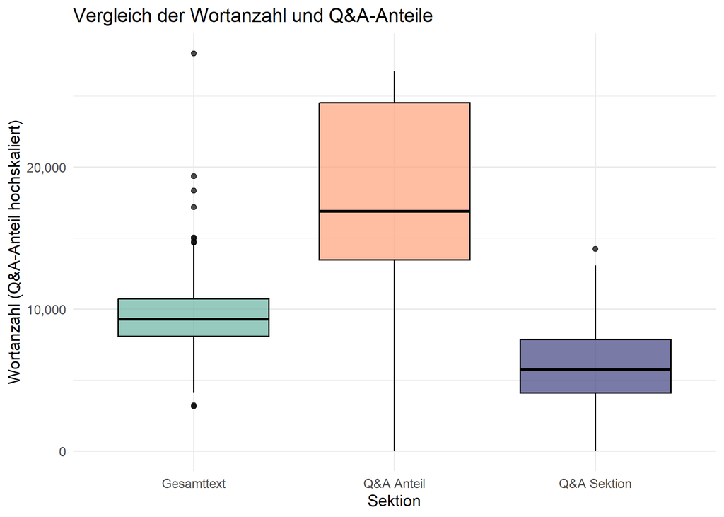

*Antwort:*

*Vergleich der Wortanzahl und Q&A-Anteile in Earnings Calls:*

Die dargestellte Grafik zeigt einen Vergleich der Wortanzahl in unterschiedlichen Teilen der Earnings Conference Call-Transkripte, dem Gesamttext, der Q&A-Sektion sowie dem skalierten Anteil der Q&A-Sektion am Gesamttext. Die Darstellung erfolgt über drei Boxplots auf einer einheitlichen y-Achse, wobei der Q&A-Anteil zur besseren Vergleichbarkeit mit den absoluten Wortanzahlen des Gesamttexts hochskaliert wurde.

*Gesamttext: Hohe Wortanzahl mit breiter Streuung:*

Die Boxplot-Darstellung des Gesamttexts zeigt, dass die Earnings Calls im Median etwa 9.000 Wörter umfassen. Der Interquartilsabstand (IQR) reicht dabei grob von 8.000 bis 11.000 Wörtern, was eine relativ einheitliche Länge der meisten Transkripte vermuten lässt. Gleichzeitig deuten die zahlreichen Ausreißer, die bis über 20.000 Wörter reichen, auf einzelne sehr umfangreiche Calls hin, etwa bei Unternehmen mit komplexen Geschäftsmodellen oder umfangreichen Analystenrunden.

*Q&A-Sektion:*

Die tatsächliche Wortanzahl in der Q&A-Sektion liegt etwas unterhalb der des Gesamttexts, mit einem Median von rund 6.000 Wörtern. Der Interquartilabstand reicht von 4.000 bis 8.000. Auch hier zeigt sich eine gewisse Streuung, wobei jedoch weniger extreme Ausreißer (über 14.000) auftreten als beim Gesamttext. Dies legt nahe, dass die Q&A-Teile in ihrer Länge stärker standardisiert sind, möglicherweise durch zeitliche Begrenzungen oder formale Vorgaben.

*Fazit:*

Insgesamt veranschaulicht die Grafik, dass Earnings Calls nicht nur umfangreich sind, sondern dass der Frage-Antwort-Teil einen wesentlichen, strukturell relevanten Anteil ausmacht. Durch die einheitliche Skalierung lassen sich die relativen und absoluten Wortmengen sinnvoll vergleichen. Für die Sentimentanalyse bedeutet dies, dass eine isolierte Betrachtung der Q&A-Sektion methodisch sinnvoll ist, sowohl aufgrund ihres Umfangs als auch wegen ihrer potenziell größeren Aussagekraft hinsichtlich Markterwartungen und -reaktionen.

## Themenkategorien und Sentiment-Scores

Nachdem Sie nun die Earnings Conference Calls in R eingelesen und einen ersten Eindruck von deren Inhalt erhalten haben sollten Sie diese mit einem LLM (konkret mit Google Gemini) analysieren. Dafür sollten Sie einen Zero-Shot Prompt erstellen und mit Hilfe dieses Prompts die Aussage der Q&A Sektionen der Earnings Conference Calls analysieren.

9. Entwickeln Sie einen Zero-Shot Prompt für ein Large Language Model (LLM), der Earnings Conference Call Transcripts analysiert und strukturierte Sentiment-Bewertungen ausgibt. Bitte beachten Sie dabei folgende Punkte:

Zielkategorien:

- Unternehmensperformance (Finanzlage, Wachstumschancen, Unternehmensrisiken)
- Marktumfeld (Branche, Wettbewerb, externe Faktoren)

Output-Format:

- JSON-Struktur mit Sentiment-Scores von -1 (sehr negativ) bis +1 (sehr positiv)
- Keine zusätzlichen Erklärungen oder Markdown-Formatierung

Sie sollten in ihrem Prompt nach einem JSON Output verlangen (strukturiertes Format), welchen Sie mit dem Paket `jsonlite` gut in R verarbeiten können.

*Hinweis 1:* Im Anhang ist eine Erklärung für die Unterschiede zwischen einem Zero-Shot Prompt, einem One-Shot Prompt und einem Few-Shot Prompt

*Hinweis 2:* Wir haben Ihnen ein [Tutorial zusammengestellt](https://projektkurs-data-science-ulm2425.netlify.app/tutorials/zero-prompting), welches das Prompting an einem Beispiel zeigt.

```r
prompt_firm_qa <- function(text) {
  sprintf(
'Sie sind ein hochspezialisierter KI-Assistent für die Analyse von Earnings Conference Call-Transkripten. Ihre Aufgabe ist es, den Sentiment-Wert des bereitgestellten Fragen-und-Antworten-Abschnitts eines Earnings Calls präzise zu bewerten und das Ergebnis in einer strukturierten JSON-Ausgabe zu liefern.

**Erläuterung der Stimmungswerte:**
Die Stimmungswerte müssen ein Fließkommawert zwischen **-1 (sehr negativ)** und **+1 (sehr positiv)** sein.
* **+1 (sehr positiv):** Die Aussage drückt eine sehr starke positive Entwicklung, Erwartung oder Einschätzung aus. Klare Indikatoren für Erfolg, Stärke oder Optimismus.
* **+0.5 (positiv):** Eine klare positive Tendenz, aber möglicherweise mit geringfügigen Vorbehalten oder weniger ausgeprägt als "sehr positiv".
* **0.0 (neutral):** Die Aussage ist faktisch, deskriptiv und enthält keine erkennbaren positiven oder negativen emotionalen Färbungen. Es werden lediglich Informationen mitgeteilt.
* **-0.5 (negativ):** Eine klare negative Tendenz, jedoch nicht alarmierend oder katastrophal. Hinweise auf Herausforderungen, Rückgänge oder Schwierigkeiten.
* **-1 (sehr negativ):** Die Aussage deutet auf erhebliche Probleme, schwerwiegende Risiken, starke Rückgänge oder großen Pessimismus hin.

**Detaillierte Zielkategorien zur Sentiment-Analyse:**

* **Unternehmensperformance:** Hier geht es um die internen Aspekte und die direkte Leistung des Unternehmens.
    * **Finanzlage:** Bezieht sich auf Kennzahlen wie Umsatz, Gewinn, Margen, Cashflow, Verschuldung und Rentabilität.
    * **Wachstumschancen:** Bewertet die Aussichten auf Expansion, neue Märkte, Produktinnovationen, strategische Investitionen und zukünftige Ertragssteigerungen.
    * **Unternehmensrisiken:** Umfasst interne Schwachstellen, operative Herausforderungen, Managementprobleme, rechtliche Risiken oder andere Faktoren, die den Unternehmenserfolg gefährden könnten.

* **Marktumfeld:** Diese Kategorie betrachtet externe Faktoren, die das Unternehmen beeinflussen.
    * **Branche:** Analysiert die allgemeine Gesundheit der Branche, Trends, regulatorische Änderungen, technologische Entwicklungen oder Strukturveränderungen innerhalb des Sektors.
    * **Wettbewerb:** Bewertet die Dynamik des Wettbewerbs, die Positionierung gegenüber Konkurrenten, Preisdruck oder neue Marktteilnehmer.
    * **Externe Faktoren:** Berücksichtigt makroökonomische Bedingungen (Inflation, Zinsen, BIP-Wachstum), geopolitische Ereignisse, Lieferkettenprobleme, Naturkatastrophen oder andere externe Einflüsse.

**Beispiele zur Orientierung für die Sentiment-Bewertung in den Unterkategorien:**

**Unternehmensperformance**
* **Finanzlage**
    * Positiv (+0.8): "Unser Umsatz im letzten Quartal übertraf die Erwartungen um 10 %, und wir konnten unsere operativen Margen durch Effizienzsteigerungen um 200 Basispunkte verbessern."
    * Negativ (-0.7): "Leider verzeichneten wir einen unerwarteten Rückgang des Gewinns um 15 % aufgrund gestiegener Rohstoffkosten, was unseren Free Cashflow erheblich beeinträchtigte."
* **Wachstumschancen**
    * Positiv (+0.9): "Wir sehen enorme Wachstumschancen durch unsere kürzlich eingeführte KI-Plattform, die bereits großes Kundeninteresse generiert und uns Zugang zu einem völlig neuen Marktsegment verschafft."
    * Negativ (-0.6): "Unsere Expansionspläne in Asien verzögern sich aufgrund unvorhergesehener regulatorischer Hürden, was unsere kurz- und mittelfristigen Wachstumsaussichten dämpft."
* **Unternehmensrisiken**
    * Positiv (+0.1 - hier eher eine Minimierung des Risikos): "Wir haben umfassende Maßnahmen ergriffen, um die identifizierten Lieferkettenrisiken zu mindern, und sehen uns nun besser aufgestellt, auch wenn eine gewisse Anfälligkeit bestehen bleibt."
    * Negativ (-0.9): "Eine aktuelle Gerichtsentscheidung stellt ein signifikantes juristisches Risiko dar, das potenziell hohe Schadensersatzforderungen nach sich ziehen und unsere Bilanz stark belasten könnte."

**Marktumfeld**
* **Branche**
    * Positiv (+0.7): "Der Gesamtmarkt für erneuerbare Energien wächst weiterhin exponentiell, getrieben durch globale Klimaziele, was uns Rückenwind für die kommenden Jahre verschafft."
    * Negativ (-0.5): "Die Automobilbranche befindet sich in einem Abschwung, und wir sehen eine allgemeine Investitionszurückhaltung bei unseren Kunden, was das Geschäftsumfeld erschwert."
* **Wettbewerb**
    * Positiv (+0.6): "Unsere jüngste Produktinnovation hat uns einen deutlichen Wettbewerbsvorteil verschafft, da wir nun Funktionen anbieten, die unsere Konkurrenten noch nicht replizieren können."
    * Negativ (-0.8): "Der aggressive Preiskampf durch neue Wettbewerber im Bereich Cloud-Dienste setzt unsere Margen massiv unter Druck und führt zu Marktanteilsverlusten."
* **Externe Faktoren**
    * Positiv (+0.4): "Die staatlichen Subventionen für grüne Technologien haben sich als sehr förderlich erwiesen und unterstützen unsere Projekte im Bereich nachhaltige Infrastruktur."
    * Negativ (-0.7): "Die anhaltend hohe Inflation und die steigenden Zinsen belasten die Konsumausgaben erheblich, was sich direkt auf unsere Einzelhandelssparte auswirkt."


**Output-Anweisung:**
Die Ausgabe muss **strikt im JSON-Format** erfolgen, ohne jegliche zusätzliche Erklärungen, Prosa, Kommentare oder Markdown-Formatierung außerhalb des JSON-Objekts.

**Beispiel-Ausgabeformat:**
json
{"Unternehmensperformance": {"Finanzlage": 0.5, "Wachstumschancen": 0.7, "Unternehmensrisiken": -0.3}, "Marktumfeld": {"Branche": 0.2, "Wettbewerb": -0.6, "Externe_Faktoren": 0.1}}


**Analysieren Sie nun den folgenden Fragen-und-Antworten-Abschnitt:**

%s', text)
}
```

10. Im nächsten Schritt sollten Sie sich in das Paket [`ellmer`](https://ellmer.tidyverse.org/) einarbeiten. Durch `ellmer` erhalten Sie Zugriff auf alle gängigen LLMs mittels R über einen API Zugang. Wir haben ihnen für dieses Projekt ein Google Konto pro Gruppe erstellt und den API Schlüssel für jede Gruppe in das dazugehörige Repo (Readme) gepushed.
- Lesen Sie sich in das [`ellmer`](https://ellmer.tidyverse.org/) Paket ein und wie Sie den API Schlüssel für Google Gemini in ihrer .Renviron Datei hinterlegen können
- Untersuchen Sie die unterschiedlichen Modelle, die Google zur Verfügung stellt und deren Ratelimits: https://ai.google.dev/gemini-api/docs/models?hl=de

Bitte beantworten Sie folgende Fragen:

- Was sind die Vorteile/Nachteile der einzelnen Google Modelle?
- Welches (kostenlose) Modell würden Sie für ihre aktuellen Analysen bevorzugt einsetzen? Begründen Sie!
- Welche Möglichkeiten haben Sie, nicht in die Ratelimits zu kommen?
- In `ellmer` können Sie mittels dem [`params()`](https://www.tidyverse.org/blog/2025/05/ellmer-0-2-0/#parameters) Parameter auch die Temperatur ihres Modells einstellen. Was ist mit der Temperatur gemeint und was sind die Vorteile/Nachteile einer niedrigen Temperatur?

*Antwort:*

*Vorteile/Nachteile der einzelnen Google Modelle?:*

Google bietet verschiedene Modelle an, die jeweils für unterschiedliche Anwendungsfälle optimiert sind und spezifische Vor- und Nachteile mit sich bringen.

**Gemini Pro** ist ein vielseitiges Modell, das sich als guter Allrounder für eine breite Palette von Aufgaben bewährt hat. Seine Stärke liegt in der guten Balance zwischen Leistung und den damit verbundenen Kosten und Rate Limits, was es zu einer effizienten Wahl für viele allgemeine Anwendungsbereiche macht.

**Gemini Ultra** repräsentiert das leistungsstärkste Modell und ist für hochkomplexe Aufgaben konzipiert, die ein tiefes Verständnis und fortgeschrittene Schlussfolgerungen erfordern. Der Nachteil hierbei ist eine potenziell höhere Latenz bei der Verarbeitung und die Möglichkeit höherer Kosten oder strengerer Rate Limits, da es nicht immer kostenlos verfügbar ist.

**Gemini Nano** wurde speziell für On-Device-Anwendungen entwickelt, die einen geringen Ressourcenverbrauch erfordern, wie zum Beispiel auf Smartphones oder Edge-Geräten. Sein Hauptnachteil ist, dass es für komplexe Cloud-basierte Analysen, die eine höhere Rechenleistung benötigen, weniger leistungsstark ist.

Es ist außerdem wichtig, die Spezifikationen der Modelle zu beachten. Dazu gehören die Größe des Kontextfensters, das bestimmt, wie viel Text das Modell gleichzeitig verarbeiten kann, ein größerer Kontext ist vorteilhaft für lange Transkripte wie Earnings Calls. Auch die verfügbaren Modalitäten (ob das Modell nur Text, oder auch Bilder und Videos verarbeiten kann) und die Sprachunterstützung sind entscheidend für die Auswahl des richtigen Modells.

*Bevorzugte Modelle für die aktuelle Analyse*

Für die Analyse von Earnings Conference Call Transkripten, die oft längere Texte umfassen und ein gutes Verständnis des gesamten Kontextes erfordern, wäre **Gemini Pro** in der Regel die bevorzugte Wahl.

Die Begründung dafür liegt in seiner ausgewogenen Leistungsfähigkeit und einer angemessenen Kontextfenstergröße. **Gemini Pro** ist zudem in den Basisanfragen in der Regel kostenlos verfügbar, was es besonders attraktiv für akademische oder nicht-kommerzielle Projekte macht. Für eine **Zero-Shot-Sentimentanalyse** ist eine exzellente Sprachverständnis-Fähigkeit entscheidend, die **Gemini Pro** bietet, ohne die höheren Anforderungen und potenziellen Kosten von **Gemini Ultra** oder die Einschränkungen der Leistungsfähigkeit von **Gemini Nano** in Kauf nehmen zu müssen.

*Möglichkeiten um nicht in die Ratelimits zu kommen:*

Um zu vermeiden, dass Sie bei der Nutzung der Google-Modelle auf Rate Limits stoßen, gibt es verschiedene Strategien, die Sie anwenden können:

Eine Möglichkeit ist das Batching von Anfragen, bei dem Sie versuchen, mehrere Anfragen in einer einzigen API-Anfrage zu bündeln. Dies ist jedoch für individuelle Transkript-Analysen oft weniger relevant. Eine weitere effektive Methode ist die Backoff-Strategie (Exponential Backoff). Wenn Sie eine Rate-Limit-Fehlermeldung erhalten, warten Sie eine kurze, exponentiell ansteigende Zeitspanne, bevor Sie die Anfrage wiederholen. Das `ellmer`-Paket könnte hierfür eingebaute Mechanismen bieten, oder Sie müssen dies manuell in Ihrem Code implementieren. Das Drosseln von Anfragen durch Implementierung einer festen Verzögerung zwischen den einzelnen Anfragen stellt sicher, dass Sie die Rate-Limit-Schwelle nicht überschreiten. Bei größeren Datenmengen kann auch eine asynchrone Verarbeitung hilfreich sein, um die Blockierung Ihres Hauptprogramms zu vermeiden, während Sie auf die Antworten warten. Für wiederkehrende Anfragen mit denselben Ergebnissen können Sie Caching nutzen, indem Sie die Ergebnisse lokal speichern, anstatt die API erneut aufzurufen. Es ist auch ratsam, die API-Nutzung zu optimieren, indem Sie nur die unbedingt notwendigen Daten an das Modell senden. Schließlich können Sie für ernsthafte Produktionsanwendungen versuchen, höhere Limits bei Google zu beantragen, aber dies ist in der Regel nicht sofort verfügbar oder kostenlos.

*Was mit der Temperatur gemeint ist und die Vorteile/Nachteile einer niedrigen Temperatur*

Die Temperatur ist ein entscheidender Parameter, der die Zufälligkeit oder Kreativität der Modellausgabe steuert. Sie beeinflusst maßgeblich, wie “überraschend” oder “konsistent” die vom Modell generierten Textsequenzen sind.

Ein höherer Temperaturwert (typischerweise zwischen 0.8 und 1.0) führt dazu, dass die Ausgabe zufälliger und vielfältiger wird. Das Modell hat eine größere Neigung, unkonventionellere oder kreativere Antworten zu generieren, indem es auch unwahrscheinlichere Token wählt. Im Gegensatz dazu führt ein niedrigerer Temperaturwert (oft zwischen 0.0 und 0.2) zu einer deterministischeren und fokussierteren Ausgabe. Das Modell wählt dabei eher die wahrscheinlichsten Wörter und generiert konsistentere, weniger “kreative” Antworten. Eine Temperatur von 0 würde bedeuten, dass das Modell bei gleicher Eingabe immer die gleiche, statistisch wahrscheinlichste Antwort liefert.

**Vorteile einer niedrigen Temperatur (z.B. 0.0 bis 0.2):**

-Konsistenz und Reproduzierbarkeit: Die Ausgaben sind bei gleicher Eingabe wesentlich konsistenter und leichter zu reproduzieren. Dies ist ein entscheidender Vorteil für Aufgaben, bei denen Genauigkeit und Zuverlässigkeit Vorrang vor Kreativität haben.

-Fokus auf Fakten/Hauptaussagen: Das Modell neigt dazu, sich auf die wahrscheinlichsten und oft faktisch korrekten oder direkt aus dem Kontext ableitbaren Informationen zu konzentrieren, was zu präziseren Ergebnissen führt.

-Weniger “Halluzinationen”: Eine niedrigere Temperatur kann dazu beitragen, dass das Modell weniger unsinnige oder irreführende Informationen generiert, da es sich stärker an die “bekanntesten” oder “wahrscheinlichsten” Antworten hält.

-Ideal für Sentimentanalyse und Extraktion: Für Aufgaben wie die Sentimentanalyse, bei der eine objektive und konsistente Bewertung gewünscht ist, oder für die Extraktion von strukturierten Daten, ist eine niedrige Temperatur oft vorteilhaft, da sie weniger Raum für Interpretation und zufällige Abweichungen lässt.

*Nachteile einer niedrigen Temperatur:*

-Mangel an Kreativität/Vielfalt: Die Ausgaben können eintönig, generisch oder sehr vorhersehbar sein. Für Aufgaben, die Brainstorming, freie Texterstellung oder das Generieren neuer, origineller Ideen erfordern, ist dies ein klarer Nachteil.

-Potenziell weniger Nuancen: Das Modell könnte subtile Bedeutungen oder indirekte Implikationen übersehen, wenn es zu stark auf die statistisch wahrscheinlichsten Antworten fixiert ist und weniger explorativ vorgeht.

-Weniger Robustheit bei mehrdeutigen Anfragen: Bei sehr mehrdeutigen oder offenen Anfragen könnte eine niedrige Temperatur dazu führen, dass das Modell nur eine einzige, möglicherweise nicht umfassende oder optimale Antwort liefert, da es weniger Alternativen in Betracht zieht.

11. Nutzen Sie ihren in Aufgabe 9 erstellten Prompt mit dem `ellmer` Paket und ihrem Google API-Key um alle 431 Earnings Conference Call Transkripte zu analysieren. Nutzen Sie für ihre Analyse das Modell Google Gemini 2.0-flash oder Google Gemini 2.5-flash.

Speichern Sie die Ergebnisse ihrer Analyse in einem strukturierten Tibble ab. Anschließend sollten Sie den Datensatz auch unter `data/sentiment.Rds` abspeichern.

Stellen Sie ihre Ergebnisse in einer Tabelle dar und beschreiben diese kurz:

- Wie ist der Mittelwert, Standardabweichung und Median der Einschätzung bezüglich Unternehmensperformance und Marktumfeld in ihren Earnings Conference Calls?

*Hinweis 1:* Achten Sie darauf nicht bei jedem Knitten die Analyse neu zu starten, sondern setzen Sie den Chunk dieser Aufgabe auf `eval = FALSE` und lassen Sie die Analyse nur einmal durchlaufen und speichern Sie die Ergebnisse ab (und laden diese später um damit weiterarbeiten zu können)

*Hinweis 2:* Achten Sie auf ihre Ratelimits und beanspruchen Sie den API Zugriff nicht zu stark, z.B. durch den Einbau von “sleep”-Zeiten in ihrem Code

Zusammenfassende Statistiken der Sentiment-Einschätzungen in Earnings Conference Calls

| Kategorie | Mittelwert | Standardabweichung | Median |
| --- | --- | --- | --- |
| Unternehmensperformance: | 0.120 | 0.135 | 0.100 |
| Finanzlage | 0.393 | 0.216 | 0.400 |
| Wachstumschancen | 0.317 | 0.171 | 0.300 |
| Unternehmensrisiken | -0.351 | 0.137 | -0.400 |
| Marktumfeld: | -0.070 | 0.145 | -0.067 |
| Branche | 0.092 | 0.249 | 0.100 |
| Wettbewerb | 0.000 | 0.025 | 0.000 |
| Externe Faktoren | -0.303 | 0.240 | -0.300 |

*Antwort:*

Die Analyse der Earnings Conference Calls anhand quantitativer Sentimentwerte offenbart differenzierte Einschätzungen zur Unternehmensperformance und zum Marktumfeld. Auf Grundlage der berechneten Kennzahlen – Mittelwert, Standardabweichung und Median – ergeben sich folgende Beobachtungen:

*Unternehmensperformance:* Die Einschätzungen zur **Finanzlage** fallen insgesamt positiv aus. Der Mittelwert liegt bei 0.393, der Median bei 0.400. Die Standardabweichung von 0.216 deutet auf eine weitgehend übereinstimmende Wahrnehmung der finanziellen Situation hin. Die **Wachstumschancen** werden ebenfalls optimistisch beurteilt. Der Mittelwert beträgt 0.317, der Median liegt bei 0.300. Die relativ geringe Streuung (Standardabweichung: 0.171) spricht für eine moderate Einigkeit unter den Einschätzungen. **Unternehmensrisiken** werden – erwartungsgemäß – kritisch eingeschätzt. Mit einem Mittelwert von -0.351 und einem Median von -0.400 zeigt sich eine überwiegend skeptische Haltung. Die Standardabweichung von 0.137 unterstreicht die Konsistenz dieser Wahrnehmung. Die allgemeine Unternehmensperformance wird leicht positiv bewertet. Der Mittelwert liegt bei 0.120, der Median bei 0.100. Mit einer Standardabweichung von 0.135 zeigt sich ein eher homogenes, verhalten optimistisches Stimmungsbild.

*Marktumfeld:* Die Einschätzungen zum externen Umfeld fallen insgesamt zurückhaltender und heterogener aus. Die Bewertung der **Branche** ist mit einem Mittelwert von 0.092 und einem Median von 0.100 nur leicht positiv. Die vergleichsweise hohe Standardabweichung von 0.249 signalisiert jedoch deutliche Unterschiede in der Wahrnehmung. Die Einschätzungen zum **Wettbewerb** sind nahezu neutral. Der Mittelwert beträgt 0.000, der Median liegt ebenfalls bei 0.000. Die sehr geringe Standardabweichung von 0.025 weist auf ein einheitliches Meinungsbild hin. **Externe Faktoren** – etwa makroökonomische Entwicklungen oder geopolitische Risiken – werden deutlich kritisch bewertet. Der Mittelwert liegt bei -0.303, der Median bei -0.300. Die hohe Standardabweichung von 0.240 zeigt, dass die Einschätzungen hierzu stark variieren – möglicherweise abhängig von Branche, Region oder Unternehmensgröße. Die Einschätzung des Marktumfelds insgesamt fällt mit einem Mittelwert von -0.070 und einem Median von -0.067 leicht negativ aus. Die Standardabweichung von 0.145 weist auf eine moderate Streuung hin.

*Fazit:* Insgesamt zeigen sich die Unternehmen in ihren Conference Calls optimistischer hinsichtlich ihrer internen Lage als im Hinblick auf das externe Umfeld. Die Finanzlage und Wachstumschancen werden überwiegend positiv wahrgenommen, während Unternehmensrisiken klar negativ, aber konsistent eingeschätzt werden. Die Einschätzungen zum Marktumfeld – insbesondere zu externen Faktoren – sind stärker gestreut und tendenziell negativer, was auf Unsicherheiten im wirtschaftlichen und geopolitischen Umfeld hinweist.

Sie haben in der vorherigen Aufgabe die Stimmung bezüglich der Kategorien Unternehmensperformance und Marktperformance in den Earnings Conference Calls bestimmt. Eine Frage wäre, ob sich diese Stimmung über die Zeit hinweg verändert hat. In der folgenden Aufgabe sollen Sie sich die durchschnittliche Stimmung in diesen zwei Kategorien für die einzelnen Jahre in ihrem Datensatz näher anschauen.

12. Erstellen Sie eine geeignete Grafik um die Stimmung *aller Earnings Conference Calls eines Jahres* zu visualisieren. Tragen Sie separat die Stimmung bezüglich Unternehmensperformance und Marktumfeld ab.

Beschreiben Sie ihre Grafik.

Interpretieren Sie diese Grafik, insbesondere im Hinblick auf die gesamtwirtschaftlichen Ereignisse der letzten fünf Jahre. Hätten Sie die Ergebnisse in dieser Art erwartet?

*Hinweis:* Sie sollten sich hier eine sinnvolle Grafik überlegen, welche die Stimmungslage über die Zeit gut darstellt.

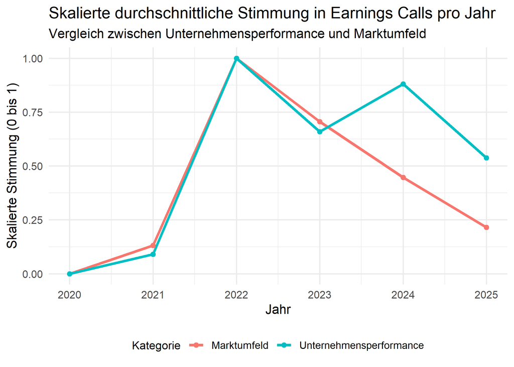

*Antwort:*

*Beschreibung:*

Die dargestellte Linie zeigt die skalierte durchschnittliche Stimmung in Earnings Conference Calls der Jahre 2020 bis 2025. Unterschieden wird dabei zwischen zwei Kategorien: Unternehmensperformance (türkis dargestellt) und Marktumfeld (rot dargestellt). Die Skalierung der Stimmung erfolgt von 0 bis 1 auf Basis einer Min-Max-Normalisierung innerhalb jeder Kategorie. Dies erlaubt einen direkten Vergleich der Entwicklung beider Kategorien über die Zeit. Für jedes Jahr wurde der Mittelwert der in diesem Jahr dokumentierten Stimmung berechnet und anschließend skaliert. Die Linien zeigen somit die Entwicklung der durchschnittlichen Stimmung in Bezug auf interne Unternehmensfaktoren sowie externe Marktbedingungen. Insgesamt fällt auf, dass sich die beiden Linien in ihrer Entwicklung ähneln, jedoch in den letzten beiden Jahren (2024 und 2025) eine stärkere Trennung sichtbar wird.

*Interpretation der Stimmungstrends:*

*2020–2021: Geringe Stimmung in beiden Kategorien:*

Die Jahre 2020 und 2021 zeigen eine sehr geringe durchschnittliche Stimmung sowohl in Bezug auf die Unternehmensperformance als auch das Marktumfeld. Dies spiegelt die Unsicherheit und die negativen wirtschaftlichen Auswirkungen der COVID-19-Pandemie wider. Unternehmen sahen sich mit unterbrochenen Lieferketten, Umsatzeinbrüchen und einem allgemein angespannten Marktumfeld konfrontiert.

*2022: Höchstwert der Stimmung:*

Im Jahr 2022 steigt die Stimmung in beiden Kategorien stark an und erreicht jeweils den Höchstwert auf der skalierten Skala. Diese Entwicklung lässt sich als Ausdruck eines Optimismus nach dem Abklingen der pandemiebedingten Einschränkungen interpretieren. Unternehmen profitierten von einer wirtschaftlichen Erholung, Nachholeffekten und einem wieder stabileren Geschäftsumfeld.

*2023: Abnehmende Stimmung:*

Ab 2023 sinkt die Stimmung erneut deutlich. Die Abwärtsbewegung deutet auf neue Unsicherheiten hin, die in diesem Zeitraum verstärkt auftraten. Hierzu zählen insbesondere steigende Inflationsraten, Zinserhöhungen durch Zentralbanken, geopolitische Spannungen (z.B. der anhaltende Krieg in der Ukraine) sowie hohe Energiepreise. Unternehmen und Märkte bewerteten die Rahmenbedingungen entsprechend vorsichtiger.

*Einordnung der Ergebnisse:*

Die gezeigte Entwicklung entspricht in vielen Punkten den Erwartungen: Der pandemiebedingte Tiefpunkt in den ersten Jahren, der anschließende Aufschwung 2022 sowie die erneute Eintrübung durch globale Herausforderungen ab 2023 sind durch reale wirtschaftliche Entwicklungen erklärbar. Etwas überraschend ist jedoch der Anstieg der Stimmung zur Unternehmensperformance in 2024, trotz gleichzeitig negativer Einschätzungen des Marktumfelds. Dies deutet auf eine gewisse Resilienz einzelner Unternehmen hin, die möglicherweise von strukturellen oder technologischen Vorteilen profitieren konnten.

*Fazit:*

Die Grafik zeigt anschaulich, wie sich die durchschnittliche Stimmung in Earnings Conference Calls über die letzten Jahre entwickelt hat. Sie verdeutlicht nicht nur die Auswirkungen globaler Ereignisse auf die wirtschaftliche Einschätzung, sondern auch Unterschiede in der Bewertung interner Unternehmenslagen und externer Marktbedingungen. Die Aufspaltung der Stimmungsentwicklung ab 2024 liefert interessante Hinweise auf die Divergenz zwischen Unternehmensrealität und gesamtwirtschaftlicher Lage.

# Eventstudie

Um zu evaluieren, ob die Earnings Conference Calls tatsächlich einen Einfluss auf die Aktienkurse der einzelnen Unternehmen hatten können Sie eine sogenannte Eventstudie durchführen, welche Sie bereits in Aufgabe 1 kennen gelernt haben. Bei einer Eventstudie betrachten Sie nur die Zeit (bei uns die Tage) unmittelbar vor oder nach einem Event. In diesem Projekt ist ein Event ein Earnings Conference Call des jeweiligen Unternehmens. Sie sollen in diesem Projekt herausfinden, wie sich über alle Unternehmen hinweg die Earnings Conference Calls auf die Aktienrenditen auswirken.

13. Verbinden Sie den Datensatz über die *Stimmung der Earnings Conference Calls (sentiment.Rds)* zu den einzelnen Unternehmen mit den *abnormalen Renditen* und speichern diesen Datensatz als `gesamtdatensatz` in R ab. Sie können das RIC-Kürzel und Datum für den Join verwenden. Sollte der Earnings Conference Call an keinem Handelstag stattgefunden haben, so joinen Sie bitte mit dem darauffolgenden Handelstag.
- Für die Tage an denen ein Earnings Conference Call stattgefunden hat sollten Sie eine Variable `event` generieren, welche an dem Tag des Calls gleich 0 ist.
- Für die Tage vor dem Earnings Conference Call (Event) sollte die Variable `event` rückwärts zählen (bis zu -5). Für alle Tage nach dem Event sollte die Variable `event` fortgeführt werden (bis +5).
- Erstellen Sie eine Variable `ar_505`, welche die *abnormalen Rendite* von Tag -5 bis +5 **fortlaufend** aufsummiert
- Erstellen Sie eine Variable `car_101`, welche die kumulierte abnormale Rendite im Zeitraum -1 bis +1 um das Event beinhaltet
- Erstellen Sie weiterhin diese sechs neuen Variablen:
  - `negativ_firm` = Wenn die Unternehmensperformance als negativ eingeschätzt wird
  - `neutral_firm` = Wenn die Unternehmensperformance als neutral eingeschätzt wird
  - `positiv_firm` = Wenn die Unternehmensperformance als positiv eingeschätzt wird
  - `negativ_market` = Wenn die Marktperformance als negativ eingeschätzt wird
  - `neutral_market` = Wenn die Marktperformance als neutral eingeschätzt wird
  - `positiv_market` = Wenn die Marktperformance als positiv eingeschätzt wird
- Erstellen Sie Dummy Variablen, die 1 sind für ein bestimmtes Jahr. Bspw. eine Dummyvariable die 2020 heißt und für alle Beobachtungen im Jahr 2020 sollte diese Variable 1 sein, 0 sonst. Tun Sie dies für alle Jahre in ihrem Datensatz

*Hinweis:* Die Funktion cumsum() könnte für diese Aufgabe hilfreich sein

14. Erstellen Sie je ein Liniendiagramm für die von ihnen betrachteten Unternehmen: Eines für die Stimmung bezüglich der Unternehmensperformance und eines bezüglich der Marktperformance.

Sie sollten in ihren Grafiken die kumulierten Renditen im Zeitraum [-5,5] Tage um einen Earnings Conference Call darstellen. - Die Variable “Event” sollte die Tage vor und nach dem Earnings Conference Call enthalten ([-5,5]) und auf der x-Achse dargestellt werden - Die Variable `ar_505` sollte die durchschnittliche kumulierte abnormale Rendite für den jeweiligen Tag auf der y-Achse abtragen (für alle Unternehmen in ihrem Datensatz) - In jeder Grafik sollten Sie eine extra Linie zeichnen für Earnings Conference Calls mit einer positiven/negativen und neutralen Stimmung und deren Einfluss auf den Aktienmarkt

Beschreiben und interpretieren Sie ihre Grafik. Gehen Sie hierbei insbesondere darauf ein, welche Erwartungen Sie auf der Basis ihrer Lektüre aus Aufgabe 1 hatten und in wie weit diese Erwartungen sich erfüllt haben.

*Hinweis:* In diesen Grafiken stellen Sie nicht jedes Event (d.h. die Auswirkungen eines jeden Earnings Conference Calls) einzeln dar, sondern gesamt für alle Earnings Conference Calls.

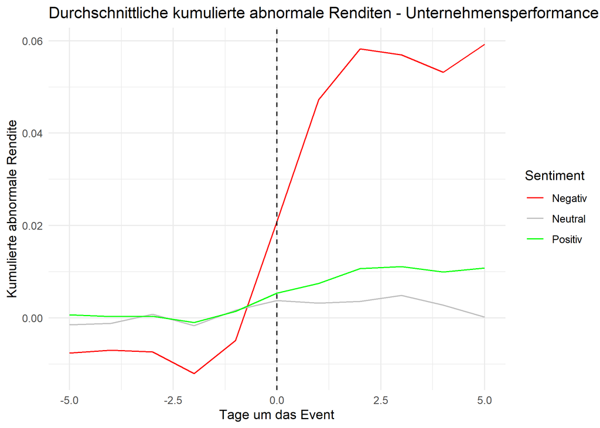

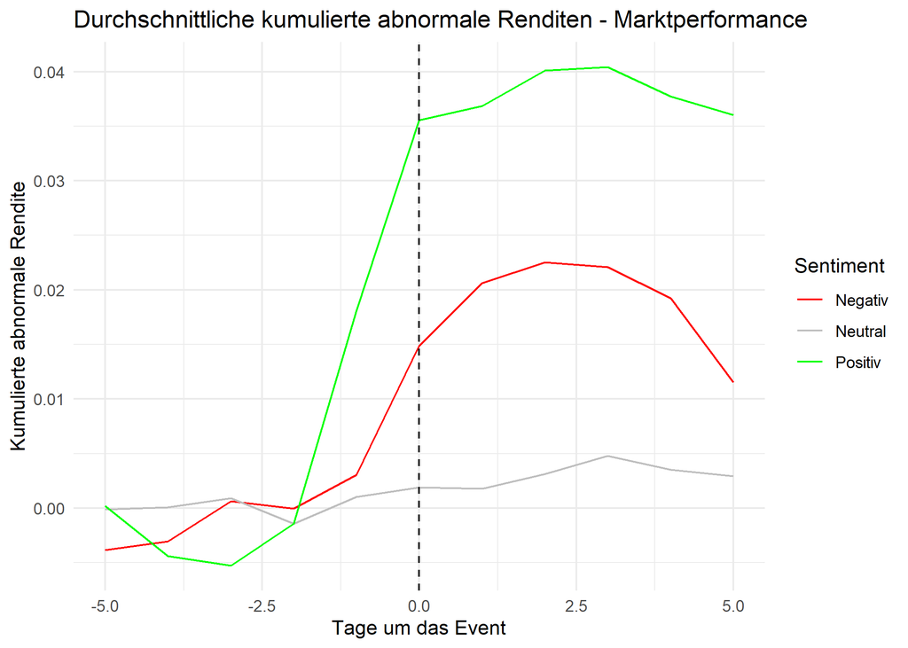

*Antwort:*

*Beschreibung und Interpretation:*

Die beiden erstellten Grafiken veranschaulichen die durchschnittlichen kumulierten abnormalen Renditen (CARs) im Zeitraum von fünf Tagen vor bis fünf Tage nach einem Event, das in diesem Fall der Earnings Conference Call ist. Die CARs werden dabei jeweils nach dem wahrgenommenen Sentiment unterteilt, das in positive, neutrale und negative Stimmung klassifiziert wurde. Zudem wird zwischen der Unternehmensperformance und der Marktperformance differenziert. Die folgende Analyse beschreibt zunächst die Ergebnisse für die Unternehmensperformance und anschließend die Ergebnisse für die Marktperformance.

*Unternehmensperformance:*

**Interpretation:**

Die Interpretation dieser Ergebnisse ist komplex, da insbesondere das Verhalten der Kurse nach negativ eingeschätzten Earnings Conference Calls nicht der allgemeinen Erwartung entspricht. Eine mögliche Erklärung dafür könnte sein, dass der Markt im Vorfeld bereits mit schlechten Nachrichten gerechnet hatte und die tatsächlichen Inhalte des Calls weniger negativ ausfielen als ursprünglich befürchtet. In einem solchen Fall kann es zu einer positiven Kursreaktion kommen, da der Markt von der realen Situation positiver überrascht wird als es die vorab bestehenden Erwartungen vermuten ließen. Eine weitere Erklärung könnte sein, dass es bei der Klassifikation des Sentiments zu Fehlern gekommen ist. Es wäre denkbar, dass der Tonfall des Calls als negativ bewertet wurde, die inhaltlichen Aussagen jedoch beispielsweise zukünftige Chancen oder Wachstumsprognosen beinhalteten, die von den Investoren positiv aufgefasst wurden. Insgesamt zeigt sich, dass die Reaktion des Marktes auf die Unternehmensperformance nicht vollständig durch die ermittelte Stimmung erklärbar ist und möglicherweise weitere Einflussfaktoren berücksichtigt werden müssten.

*Marktperformance:*

*Erwartungen aus Aufgabe 1 im Vergleich zur Realität:*

Auf Grundlage der theoretischen Auseinandersetzung in Aufgabe 1 wurde erwartet, dass ein positives Sentiment sowohl auf Unternehmens- als auch auf Marktebene zu steigenden kumulierten abnormalen Renditen führt. Im Gegenzug sollten negativ wahrgenommene Earnings Conference Calls zu fallenden oder zumindest stagnierenden CARs führen. Für neutral eingestufte Calls wurde keine signifikante Kursveränderung erwartet.

*Fazit:*

Die Abweichungen zwischen Markt- und Unternehmensperformance verdeutlichen, dass weitere Einflussfaktoren wie firmenspezifische Informationen, Investorenverhalten oder Erwartungshaltungen berücksichtigt werden sollten. Zudem bleibt das sogenannte Joint-Test-Problem bestehen, da die Ergebnisse auch durch methodische Aspekte, etwa bei der Bestimmung der Normalrenditen oder der Sentimentklassifikation, beeinflusst sein könnten. Die Ergebnisse sollten daher mit einer gewissen Vorsicht interpretiert werden. Insgesamt zeigt die Analyse jedoch, dass Earnings Conference Calls ein bedeutendes Ereignis darstellen, das von den Investoren aktiv verarbeitet wird und zu systematischen Kursbewegungen führen kann – insbesondere dann, wenn die Markterwartung durch das kommunizierte Sentiment bestätigt oder widerlegt wird.

# Regressionen

Sie haben bisher den Einfluss der Earnings Conference Calls auf die Aktienrendite der größten europäischen Unternehmen im Technologie-Sektor visuell betrachtet. Im letzten Abschnitt dieser Projektarbeit analysieren Sie ihre Daten mittels linearer Regressionen.

15. In dieser Aufgabe sollten Sie zwei Regressionen erstellen:

Regressieren Sie die kumulierten abnormalen Renditen um das Event `car_101` auf die Dummyvariablen

- `negativ_firm` und `negativ_market` in der ersten Regression und
- `positiv_firm` und `positiv_market` in der zweiten Regression.

Diese Dummyvariablen geben die Stimmung in den Earnings-Conference Calls wieder.

Beschreibung und interpretieren Sie ihre Regressionsergebnisse und gehen Sie dabei auch auf folgende Fragen ein:

- Was ist die Vergleichsgruppe in den beiden Regressionen?
- Was sind die Voraussetzungen für eine kausale Interpretation der Koeffizienten. Sind diese ihrer Meinung nach gegeben?

Regressionsergebnisse: Einfluss des Sentiments auf car_101

| Modell | Variable | Koeffizient | Standardfehler | t-Wert | p-Wert |
| --- | --- | --- | --- | --- | --- |
| Negatives Sentiment | (Intercept) | 0.005 ** | 0.002 | 2.702 | 0.007 |
|  | negativ_firm | 0.044 *** | 0.013 | 3.485 | 0.000 |
|  | negativ_market | 0.011 * | 0.005 | 2.308 | 0.021 |
| Positives Sentiment | (Intercept) | 0.006 ** | 0.002 | 3.282 | 0.001 |
|  | positiv_firm | 0 | 0.003 | -0.106 | 0.915 |
|  | positiv_market | 0.032 ** | 0.010 | 3.098 | 0.002 |

Hinweis:  
Anzahl Beobachtungen: 3047 | R² (Negativ): 0.0082 | R² (Positiv): 0.0033 | Signifikanzniveau: *** p < 0.001, ** p < 0.01, * p < 0.05, . p < 0.1

*Antwort:*

*Beschreibung und Interpretation der Regressionsergebnisse:*

Im Rahmen der durchgeführten Regressionsanalysen wurde untersucht, inwiefern sich die Stimmung der Earnings Conference Calls auf die kumulierten abnormalen Renditen (CARs) im Zeitraum von einem Tag vor bis einem Tag nach dem Event (car_101) auswirkt. Dazu wurden zwei separate Regressionen berechnet. In der ersten Regression wurde car_101 auf die Dummyvariablen negativ_firm und negativ_market regressiert, während in der zweiten Regression die Einflüsse von positiv_firm und positiv_market betrachtet wurden.

*Ergebnisse der ersten Regression: Negatives Sentiment:*

In der ersten Regression zeigt sich, dass sowohl das negative Sentiment auf Unternehmensebene (negativ_firm) als auch auf Marktebene (negativ_market) einen signifikanten Einfluss auf die kumulierten abnormalen Renditen haben. Das Interzept liegt bei etwa 0,005 und ist ebenfalls signifikant. Der Koeffizient für negativ_firm beträgt etwa 0,044 und ist hochsignifikant. Dies bedeutet, dass bei einem negativ eingeschätzten Sentiment auf Unternehmensebene die CARs im Durchschnitt um etwa 4,4 Prozentpunkte höher sind als bei der Vergleichsgruppe. Auch negativ_market zeigt mit einem Koeffizienten von etwa 0,011 einen signifikanten positiven Effekt. Der Anstieg der CARs beträgt hier im Durchschnitt rund 1,1 Prozentpunkte im Vergleich zur Referenzgruppe.

Diese Ergebnisse sind überraschend, da ein negatives Sentiment in der Theorie eher mit rückläufigen oder stagnierenden Renditen in Verbindung gebracht wird. Die positiven Vorzeichen der Koeffizienten deuten jedoch darauf hin, dass der Markt in diesen Fällen entgegen der Erwartung positiv auf negativ bewertete Earnings Conference Calls reagiert hat. Eine mögliche Erklärung dafür könnte sein, dass die negativen Erwartungen im Vorfeld bereits eingepreist waren und der tatsächliche Call als weniger negativ wahrgenommen wurde. Auch eine Fehlklassifikation des Sentiments oder eine optimistische Zukunftsprognose trotz negativem Tonfall könnten diesen Effekt verursachen.

*Ergebnisse der zweiten Regression: Positives Sentiment:*

In der zweiten Regression wurde car_101 auf positiv_firm und positiv_market regressiert. Das Interzept liegt bei rund 0,006 und ist signifikant. Während positiv_market mit einem Koeffizienten von etwa 0,032 signifikant positiv ist, zeigt positiv_firm keinen signifikanten Einfluss auf die kumulierten abnormalen Renditen. Der geschätzte Effekt von positiv_market bedeutet, dass bei positiv wahrgenommenem Marktsentiment die CARs im Durchschnitt um etwa 3,2 Prozentpunkte höher sind als in der Vergleichsgruppe.

Im Gegensatz dazu hat das positive Sentiment auf Unternehmensebene keinen erkennbaren Einfluss, da der p-Wert bei etwa 0,92 liegt und der Koeffizient nahezu null ist. Dies deutet darauf hin, dass das Marktsentiment im Vergleich zum unternehmensspezifischen Sentiment offenbar von den Investoren als wesentlich relevanter für die Kursreaktion wahrgenommen wird.

*Vergleichsgruppe in den beiden Regressionen:*

Die Vergleichsgruppe besteht in beiden Regressionen aus Earnings Conference Calls, die weder negativ noch positiv klassifiziert wurden, also den Calls mit neutralem Sentiment. Da es sich bei den Dummyvariablen um binäre Indikatoren handelt, beziehen sich die geschätzten Effekte jeweils auf den Unterschied zu dieser neutralen Vergleichsgruppe. In der ersten Regression wird also die Abweichung der CARs bei negativem Sentiment im Vergleich zu neutralem Sentiment gemessen. In der zweiten Regression wird die Abweichung der CARs bei positivem Sentiment im Vergleich zur neutralen Gruppe betrachtet.

*Voraussetzungen für eine kausale Interpretation:*

Für eine kausale Interpretation der Koeffizienten müssten mehrere Bedingungen erfüllt sein. Erstens sollte das Sentiment exogen sein, das heißt, es darf nicht systematisch mit anderen unbeobachteten Einflussfaktoren korreliert sein, die ebenfalls die CARs beeinflussen könnten. Wenn zum Beispiel Unternehmen bei schlechten Ergebnissen versuchen, das Sentiment strategisch zu steuern, könnte ein Endogenitätsproblem auftreten. Zweitens sollten alle relevanten Kontrollvariablen berücksichtigt sein, die einen Einfluss auf die CARs haben könnten. In den vorliegenden Regressionen wurde jedoch lediglich das Sentiment berücksichtigt, während potenziell wichtige Faktoren wie Unternehmensgröße, vorherige Performance oder Marktvolatilität nicht kontrolliert wurden. Somit besteht die Gefahr von omitted variable bias. Drittens sollte der Zusammenhang zwischen Sentiment und CARs tatsächlich kausal sein und nicht auf umgekehrte Kausalität oder Drittvariablen zurückzuführen sein. Beispielsweise könnte es sein, dass Unternehmen, deren Aktien bereits steigen, dazu neigen, positiver zu kommunizieren, hier bestünde ein simultanes Zusammenhangsproblem.

Vor diesem Hintergrund ist eine strikte kausale Interpretation der Ergebnisse nicht möglich. Die Ergebnisse zeigen statistische Zusammenhänge zwischen dem Sentiment und den kumulierten abnormalen Renditen, liefern jedoch keine belastbaren Hinweise auf einen kausalen Effekt. Dafür wären zusätzliche Robustheitsanalysen, Kontrollvariablen oder idealerweise experimentelle Daten nötig. In der vorliegenden Untersuchung lassen sich die Regressionskoeffizienten daher deskriptiv interpretieren, jedoch nicht kausal im strengen Sinne.

16. In ihrer deskriptiven Analyse haben Sie bereits gesehen, dass die Unternehmen, die Sie in diesem Projekt betrachten, alle unterschiedlich groß sind. Weiterhin haben Sie gesehen, dass es ein unterschiedliches Stimmungsbild in den Calls über die einzelnen Jahre hinweg gibt. Dafür möchten Sie in ihren Regressionen nun kontrollieren.
    1. Regressieren Sie die `car_101` auf die Variablen *negativ_firm* und *negativ_market* und kontrollieren Sie auf die Größe des jeweiligen Unternehmens, indem Sie die Variable *Total_Assets* in ihre Regression aufnehmen
    2. Fügen Sie in einer zweiten Analyse zusätzlich zu den Variablen aus der 1. Regression auch noch Dummyvariablen für die Jahre in dem das Event stattgefunden hat ihrer Regression hinzu.
    3. Führen Sie die Regressionen aus 1. und 2. auch für die Variablen *positiv_firm* und *positiv_market* anstatt *negativ_firm* und *negativ_market* durch, sodass Sie am Ende 4 Regressionen haben

Beschreiben und interpretieren Sie ihre Ergebnisse im Hinblick auf die Größe der Koeffizienten und deren Signifikanz. Gehen Sie insbesondere auf folgende Fragen ein:

- Warum sollte ihre Regression nicht fünf Dummyvariablen, je eine für jedes Jahr, sondern nur vier beinhalten?
- Verändert sich durch die Dummyvariablen der Koeffizient von *negativ_firm* und *negativ_market* bzw. *positiv_firm* und *positiv_market*?
- Hätten Sie eine Veränderung des Koeffizienten von *negativ_firm*, *negativ_market*, *positiv_firm* oder *positiv_market* erwartet? Begründen Sie ihre Antwort mit ihren deskriptiven Analysen.

Regressionsergebnisse: Einfluss von negativem und positivem Sentiment auf car_101

| Modell | Variable | Koeffizient | Standardfehler | t-Wert | p-Wert |
| --- | --- | --- | --- | --- | --- |
| Negatives Sentiment | (Intercept) | 0.004 | 0.002 | 1.578 | 0.115 |
|  | negativ_firm | 0.052 *** | 0.012 | 4.135 | 0.000 |
|  | negativ_market | 0.004 | 0.005 | 0.871 | 0.384 |
|  | Total_Assets | 0 | 0.000 | -0.315 | 0.753 |
| Positives Sentiment | (Intercept) | 0.004 . | 0.002 | 1.856 | 0.064 |
|  | positiv_firm | 0.002 | 0.004 | 0.587 | 0.557 |
|  | positiv_market | 0.04 *** | 0.011 | 3.646 | 0.000 |
|  | Total_Assets | 0 | 0.000 | -0.909 | 0.364 |

Hinweis:  
Anzahl Beobachtungen: 2706 | R²: Negatives Sentiment: 0.0088 | Positives Sentiment: 0.0058 | Signifikanzniveau: *** p < 0.001, ** p < 0.01, * p < 0.05, . p < 0.1

Regressionsergebnisse: Einfluss von negativem und positivem Sentiment auf car_101 mit Jahresdummies

| Modell | Variable | Koeffizient | Standardfehler | t-Wert | p-Wert |
| --- | --- | --- | --- | --- | --- |
| Negatives Sentiment mit Jahr | (Intercept) | 0.012 ** | 0.004 | 3.072 | 0.002 |
|  | negativ_firm | 0.043 ** | 0.013 | 3.408 | 0.001 |
|  | negativ_market | 0.006 | 0.005 | 1.235 | 0.217 |
|  | Total_Assets | 0 | 0.000 | -0.198 | 0.843 |
|  | factor(year(Datum))2021 | -0.009 . | 0.005 | -1.813 | 0.070 |
|  | factor(year(Datum))2022 | -0.001 | 0.005 | -0.252 | 0.801 |
|  | factor(year(Datum))2023 | -0.006 | 0.006 | -1.051 | 0.293 |
|  | factor(year(Datum))2024 | -0.028 *** | 0.005 | -5.449 | 0.000 |
| Positives Sentiment mit Jahr | (Intercept) | 0.017 *** | 0.004 | 4.477 | 0.000 |
|  | positiv_firm | 0.01 * | 0.004 | 2.503 | 0.012 |
|  | positiv_market | 0.035 ** | 0.011 | 3.078 | 0.002 |
|  | Total_Assets | 0 | 0.000 | -0.909 | 0.363 |
|  | factor(year(Datum))2021 | -0.012 * | 0.005 | -2.363 | 0.018 |
|  | factor(year(Datum))2022 | -0.015 ** | 0.006 | -2.689 | 0.007 |
|  | factor(year(Datum))2023 | -0.012 * | 0.005 | -2.236 | 0.025 |
|  | factor(year(Datum))2024 | -0.036 *** | 0.005 | -6.729 | 0.000 |

Hinweis:  
Anzahl Beobachtungen: 2706 | R²: Negatives Sentiment mit Jahr: 0.0228 | Positives Sentiment mit Jahr: 0.0229 | Signifikanzniveau: *** p < 0.001, ** p < 0.01, * p < 0.05, . p < 0.1

*Antwort:*

*Beschreibung und Interpretation der Regressionsergebnisse:*

*Koeffizientengrößen und Signifikanz:*

Die durchgeführten Regressionen zeigen, dass firmenspezifisch negative Ereignisse (negativ_firm) einen signifikanten Einfluss auf die kumulierten abnormalen Renditen haben. Im Modell ohne Jahresdummies führt ein negatives firmenspezifisches Ereignis durchschnittlich zu einer Erhöhung der kumulierten abnormalen Rendite um etwa 5,15 %. Dieser Effekt bleibt auch im Modell mit Jahresdummies bestehen, reduziert sich jedoch leicht auf etwa 4,28 %. Dies ist insofern überraschend, als eigentlich ein negativer Einfluss auf die Renditen erwartet worden wäre. Möglicherweise reagieren die Märkte in diesen Fällen mit einer Gegenbewegung oder einer Überkompensation. Im Gegensatz dazu zeigt die Variable negativ_market, die marktspezifisch negative Ereignisse abbildet, in beiden Modellen keinen signifikanten Einfluss. Das deutet darauf hin, dass der Markt in diesem Datensatz nicht systematisch auf solche Ereignisse reagiert. Die Variable Total_Assets, welche die Unternehmensgröße beschreibt, hat in allen Modellen keinen signifikanten Einfluss auf die abnormalen Renditen. Die Unternehmensgröße scheint demnach in diesem Zusammenhang keine Rolle zu spielen. Für positive Ereignisse ergibt sich ein anderes Bild: Die Variable positiv_market ist in beiden Modellen signifikant positiv und zeigt, dass marktspezifisch positive Ereignisse im Durchschnitt mit einem Anstieg der abnormalen Renditen um ca. 3,5 % bis 4 % verbunden sind. Die Variable positiv_firm ist ohne Jahresdummies nicht signifikant, wird jedoch im Modell mit Jahresdummies signifikant und zeigt einen positiven Effekt von etwa 1 %. Die Kontrolle der Jahre scheint also einen Teil des Störens aus dem Modell zu entfernen und den Effekt firmenspezifisch positiver Ereignisse sichtbar zu machen. Die Jahresdummies sind insbesondere im Jahr 2024 hoch signifikant. Das deutet darauf hin, dass es in diesem Jahr systematisch negative Renditen gab, die nicht durch die Eventvariablen erklärt werden können. Dies kann beispielsweise auf makroökonomische Schocks oder branchenspezifische Entwicklungen zurückzuführen sein.

*Notwendigkeit der Jahresdummies:*

In der Regression sollten nicht fünf Dummyvariablen, eine für jedes Jahr, eingebaut werden, sondern lediglich vier. Der Grund dafür ist die sogenannte „Dummy-Variable Trap“. Wenn für jede Kategorie (in diesem Fall jedes Jahr) ein Dummy in das Modell aufgenommen wird, entsteht perfekte Multikollinearität, da die Dummies zusammen mit dem Intercept die Information zu 100 % abbilden würden. Dies würde das Regressionsmodell unlösbar machen. Die Lösung besteht darin, ein Jahr als Referenzkategorie (in diesem Fall das Jahr 2020) auszuschließen. Die Effekte der verbleibenden Dummies werden dann relativ zu diesem Basisjahr interpretiert. Beispielsweise zeigt der negative Koeffizient der Dummyvariable für das Jahr 2024, dass die abnormalen Renditen in diesem Jahr im Durchschnitt niedriger waren als im Referenzjahr 2020.

*Veränderung der Koeffizienten durch Jahresdummies:*

Durch die Einbeziehung der Jahresdummies verändern sich die Koeffizienten der Eventvariablen teilweise. Der Koeffizient von negativ_firm sinkt von ca. 5,15 % auf 4,28 %, bleibt jedoch signifikant. Der Koeffizient von negativ_market bleibt unverändert insignifikant. Interessanterweise wird der Koeffizient von positiv_firm im Modell mit Jahresdummies signifikant, während er im Modell ohne diese Kontrolle nicht signifikant war. Dies spricht dafür, dass Jahresunterschiede, also allgemeine makroökonomische Entwicklungen oder Branchenphasen, die Schätzung beeinflussen. Durch die Kontrolle der Jahre wird der Effekt des positiven firmenspezifischen Ereignisses klarer sichtbar. Auch der Effekt von positiv_market reduziert sich leicht, bleibt aber signifikant. Diese Veränderungen zeigen, dass die Einbeziehung von Jahresdummies essenziell ist, um Effekte von zeitlichen Schwankungen zu trennen und die Eventeffekte korrekt zu identifizieren.

*Erwartete Veränderungen der Koeffizienten:*

Eine Veränderung der Koeffizienten durch die Aufnahme der Jahresdummies war grundsätzlich zu erwarten. Die deskriptiven Analysen haben bereits angedeutet, dass die kumulierten abnormalen Renditen zwischen den Jahren schwanken und sich Marktentwicklungen unterschiedlich auf die Renditen ausgewirkt haben. Ohne Jahresdummies könnten allgemeine Trends fälschlicherweise den Ereignisvariablen zugeschrieben werden. Die Kontrolle für das Jahr stellt sicher, dass nur die spezifischen Effekte des jeweiligen Ereignisses gemessen werden. Besonders bei der Variable positiv_firm war die Veränderung des Koeffizienten erwartbar. In den deskriptiven Analysen zeigte sich vermutlich, dass sich die Renditen über die Jahre hinweg verändert haben und dass positive Ereignisse nicht in allen Jahren gleich häufig oder gleich stark vorgekommen sind. Die Aufnahme der Jahresdummies trennt diesen systematischen Zeiteffekt von den spezifischen Eventeffekten, was die Signifikanz und die Größe des Koeffizienten beeinflusst.

17. Zum Abschluss sollten Sie dazu Stellung beziehen, in wie weit die Erkenntnisse aus diesem Projekt für eine Handelsstrategie genutzt werden könnten. Konkret sollten Sie erläutern ob es sinnvoll ist eine Unternehmensaktie bei einem negativem Sentiment im Earnings Conference Call automatisiert zu verkaufen.

Beziehen Sie sich in ihrer Argumentation insbesondere auf:

- Zeitliche Aspekte (Wann reagiert der Markt vs. wann liegt das Sentiment vor?)
- Methodische Limitationen Ihrer Event Study
- Unsicherheiten bei der LLM-Sentiment-Analyse

Begründen Sie jeden Kritikpunkt konkret mit Bezug auf Ihre Projektarbeit und schließen Sie mit einer realistischen Einschätzung ab: Wofür könnten Ihre Ergebnisse trotz dieser Limitationen in der Praxis dennoch wertvoll sein?

*Antwort:*

*Stellungnahme zur Nutzbarkeit der Ergebnisse für eine Handelsstrategie:*

Automatisierter Verkauf bei negativem Sentiment in Earnings Conference Calls, sinnvoll oder nicht? Die Idee, Unternehmensaktien automatisiert zu verkaufen, wenn ein Large Language Model (LLM) während eines Earnings Conference Calls ein negatives Sentiment identifiziert, erscheint auf den ersten Blick plausibel. Die Ergebnisse der vorliegenden Analyse zeigen jedoch, dass eine solche Handelsstrategie nur eingeschränkt sinnvoll wäre. Verschiedene zeitliche, methodische und analytische Aspekte sprechen gegen eine unmittelbare Umsetzung.

*Zeitliche Aspekte, Marktreaktion vs. Verfügbarkeit des Sentiments:*

Der Kapitalmarkt reagiert in der Regel innerhalb von Minuten oder wenigen Stunden auf neue Informationen, die während eines Earnings Conference Calls veröffentlicht werden. Das in diesem Projekt verwendete LLM-basierte Sentiment wird jedoch in der Regel erst im Nachgang auf Basis der vollständigen Transkripte ermittelt. Das bedeutet, dass die Erhebung des Sentiments zeitlich verzögert erfolgt und der Markt in vielen Fällen bereits auf die Informationen reagiert hat, bevor das Sentiment zur Verfügung steht. Die Folge ist, dass ein automatisierter Verkauf auf Basis des LLM-Sentiments zu spät erfolgen würde. Für kurzfristige Handelsstrategien, insbesondere im Bereich des High-Frequency-Trading, wäre diese Verzögerung ein erheblicher Nachteil. Der potenzielle Gewinn aus einer schnellen Reaktion wäre damit in den meisten Fällen bereits realisiert oder verloren.

*Methodische Limitationen der Event-Study:*

Die in diesem Projekt durchgeführte Event-Study misst durchschnittliche Renditeeffekte über eine Vielzahl von Unternehmen und Ereignissen hinweg. Die Methode erlaubt es nicht, valide Aussagen über die Kursentwicklung einzelner Aktien im spezifischen Einzelfall zu treffen. Zudem basiert die Analyse auf retrospektiven Daten: Die abnormalen Renditen sind ex-post gemessen und nicht im Vorfeld prognostizierbar. Dies schränkt die Möglichkeit ein, die Ergebnisse unmittelbar für konkrete Handelsentscheidungen zu nutzen. Ein Beispiel aus der eigenen Analyse verdeutlicht dies: In den deskriptiven Darstellungen (siehe Unternehmensperformance-Grafik) steigen die abnormalen Renditen teilweise trotz eines als negativ klassifizierten Sentiments. Solche Ergebnisse widersprechen der Annahme, dass ein negatives Sentiment stets zu fallenden Kursen führt, und zeigen die Grenzen einer pauschalen Verkaufsregel.

*Unsicherheiten bei der LLM-Sentiment-Analyse:*

Ein weiterer kritischer Punkt betrifft die Qualität der Sentiment-Analyse durch Large Language Models. LLMs bewerten das Sentiment auf Basis sprachlicher Strukturen und Schlüsselbegriffe, jedoch ohne Berücksichtigung des betriebswirtschaftlichen Kontexts. Begriffe wie „Rückgang“ oder „Problem“ können auch in positiven Zusammenhängen verwendet werden, etwa wenn sich ein Rückgang als weniger gravierend als erwartet herausstellt. Besonders problematisch sind Situationen, in denen Earnings Calls vorsichtig formuliert oder ambivalente Aussagen getroffen werden. Hier besteht ein erhöhtes Risiko von Fehlklassifikationen durch das Modell. Ein negatives Sentiment muss somit nicht zwangsläufig eine negative Kursreaktion nach sich ziehen. Diese Unsicherheit reduziert die Aussagekraft der Sentiment-Analyse für eine automatisierte Handelsentscheidung deutlich.

*Realistische Einschätzung: Wofür sind die Ergebnisse dennoch nützlich?:*

Trotz der genannten Limitationen können die gewonnenen Erkenntnisse für andere Anwendungsbereiche von hohem praktischem Nutzen sein:

-Portfolio-Strategien: Eine aggregierte Betrachtung von Sentiments über viele Unternehmen hinweg kann Markt- oder Branchentrends aufzeigen und wertvolle Hinweise für die Portfolioallokation liefern.

-Risikomanagement: Ein stark negatives Sentiment kann als Frühwarnsignal dienen, das Anlass für eine vertiefte Einzelfallanalyse oder ein Risikoscreening gibt.

-Investor Relations und Kommunikationsstrategien: Die Ergebnisse helfen zu verstehen, wie bestimmte Kommunikationsmuster von Investoren interpretiert werden. Unternehmen können daraus wichtige Rückschlüsse für die Gestaltung ihrer zukünftigen Earnings Calls ziehen.

*Fazit: Kein automatisierter Verkauf, aber strategischer Mehrwert:*

Ein automatisierter Verkauf von Unternehmensaktien auf Basis eines LLM-basierten negativen Sentiments ist nach den vorliegenden Ergebnissen nicht empfehlenswert. Sowohl die zeitliche Verzögerung, als auch die methodischen Einschränkungen der Event-Study und die Unsicherheiten bei der Sentiment-Analyse sprechen gegen eine solche Strategie. Dennoch bietet die systematische Analyse von Earnings Conference Calls einen bedeutenden strategischen Mehrwert. Insbesondere für übergeordnete Portfolioentscheidungen, für das Risikomanagement und zur Optimierung der Unternehmenskommunikation kann das Sentiment ein hilfreicher Indikator sein.

# Zusatzaufgabe

In Aufgabe 6 berechnen Sie die *abnormalen Renditen* der einzelnen von ihnen betrachteten Unternehmen. Nun könnte es allerdings sein, dass es nicht ausreicht den Marktindex einfach von der Aktienrendite abzuziehen um für die erwartete Performance der Aktie zu kontrollieren. Potentiell wäre es besser für die durchschnittliche Performance der Aktie zu kontrollieren in der keine Events stattfinden.

Sie können eine solche durchschnittliche Performance schätzen. Dazu sollten Sie eine Schätzperiode *vor* dem Event definieren. Diese Periode sollen Sie auf 120 bis 10 Handelstage vor dem Event festlegen. Die durchschnittliche Rendite der Einzelaktie sollten Sie in dieser Periode auf die Marktrendite regressieren. Dieses Modell wird `Risk-adjusted returns model` in Huntington-Klein (2021) genannt:

$$\begin{equation}
\hat{Rendite}_{i,t} = \alpha + \beta Rendite_{m,t}
\end{equation}$$

Anschließend nutzen Sie die vorhergesagten Werte und ziehen diese in der Eventphase von der Rendite der Einzelaktie ab.

18. Erstellen Sie die kumulierten abnormalen Renditen im Zeitraum -5 bis +5 mit Hilfe ihres Risk-adjusted returns model neu (und nennen diese `mar_505`). Erstellen Sie die kumulierten abnormalen Renditen im Zeitraum -1 bis +1 um das Event mit Hilfe ihres Risk-adjusted returns model neu (und nennen die Variable `cmar_101`) und vergleichen die Werte in einer geeigneten Grafik mit den Ergebnissen aus dem market-adjusted returns model (`car_101`).
- Gibt es hier große Unterschiede?
- Warum gibt es diese Unterschiede, oder warum sehen Sie nur geringe Unterschiede?

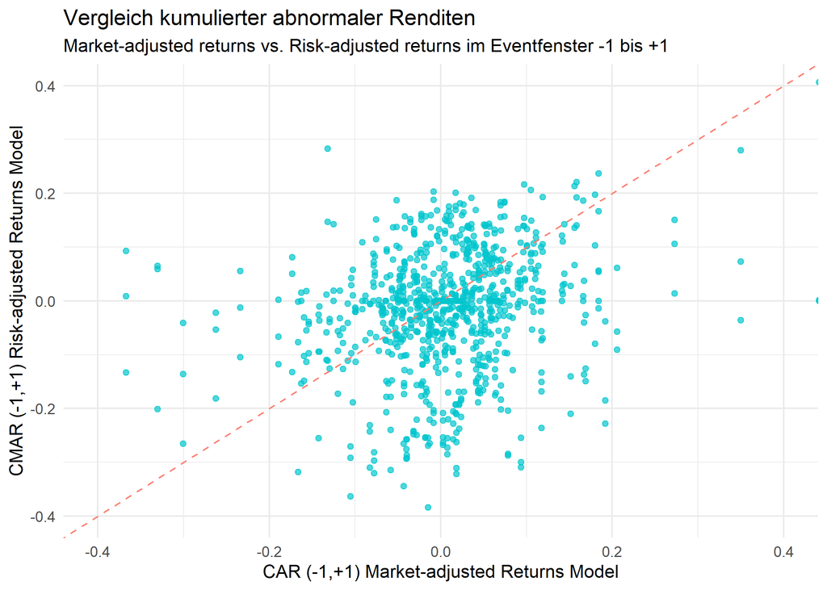

*Antwort:*

*Analyse des Diagramms:*

Das dargestellte Diagramm ist ein Scatterplot, der die Beziehung zwischen zwei Arten von kumulierten abnormalen Renditen zeigt: auf der X-Achse sind die markt-adjustierten Renditen (CAR (-1,+1)) und auf der Y-Achse die risiko-adjustierten Renditen (CMAR (-1,+1)) abgetragen.

*Gibt es hier große Unterschiede?:*

Ursprünglich war die Erwartung, dass beide Modelle zu ähnlichen Ergebnissen führen würden, da sie denselben Ereigniszeitraum abbilden und lediglich unterschiedliche Berechnungsmethoden verwenden. Beim Vergleich zeigt sich jedoch, dass diese Erwartung nur teilweise erfüllt wird. Zwar liegen viele Punkte nahe der Diagonalen, was auf eine gewisse Übereinstimmung zwischen den beiden Methoden hindeutet, dennoch sind auch deutliche Abweichungen zu erkennen.

*Warum gibt es diese Unterschiede, oder warum sehen Sie nur geringe Unterschiede?:*

Die Unterschiede zwischen den beiden Renditemodellen lassen sich durch mehrere Faktoren erklären:

-Modellannahmen und Berechnungsmethoden: Das markt-adjustierte Modell vergleicht die Aktienrendite direkt mit dem allgemeinen Marktindex, während das risiko-adjustierte Modell unternehmensindividuelle Betafaktoren berücksichtigt. Dadurch können schon methodisch unterschiedliche Werte entstehen, insbesondere bei Unternehmen mit hoher oder niedriger Marktsensitivität.

-Schätzperioden und Datenqualität: Das risiko-adjustierte Modell basiert auf einer vorhergehenden Schätzperiode (z. B. 120 Handelstage), in der ein Regressionsmodell geschätzt wird. Geringe Datenverfügbarkeit oder instabile Schätzparameter können die Ergebnisqualität beeinflussen.

-Volatilität und Event-spezifische Effekte: In Phasen hoher Marktvolatilität oder bei firmenspezifischen Nachrichten können die Reaktionen der Renditen sehr unterschiedlich  
ausfallen. Dies wird im risiko-adjustierten Modell möglicherweise besser erfasst als im markt-adjustierten Modell, oder umgekehrt.

-Marktunvollkommenheiten: Theoretische Modelle gehen oft von effizienten Märkten aus. In der Realität können jedoch Marktanomalien, zeitverzögerte Reaktionen oder geringe Liquidität dazu führen, dass sich die tatsächlichen Renditen anders verhalten als erwartet.

*Fazit:*

Insgesamt zeigt sich, dass es zwar eine erkennbare Beziehung zwischen CAR und CMAR gibt, die beiden Modelle jedoch in vielen Fällen zu unterschiedlichen Ergebnissen führen. Diese Unterschiede sind nicht zufällig, sondern auf strukturelle Abweichungen in der Modelllogik und auf unterschiedliche Markteinflüsse zurückzuführen. Dies verdeutlicht, wie wichtig die bewusste Auswahl des Bewertungsmodells in einer Eventstudie ist.

19. Erstellen Sie die Grafik von Aufgabe 14 neu.

Beschreiben und interpretieren Sie ihre Grafik. Gehen Sie auch auf folgende Fragen ein:

- Könnte es zu Problemen führen, wenn in der Schätzperiode vor dem Event ein weiterer Earnings-Conference Call enthalten ist?
  - Warum könnte dies ein Problem sein, oder warum nicht?

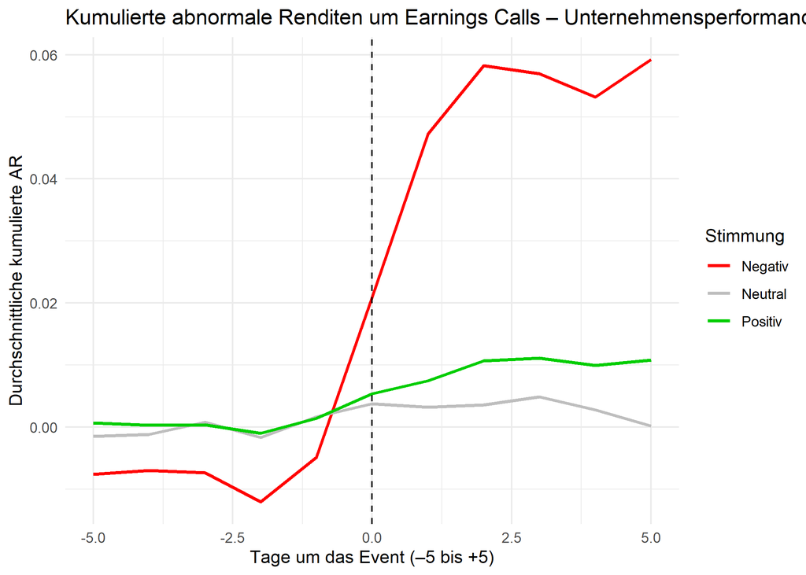

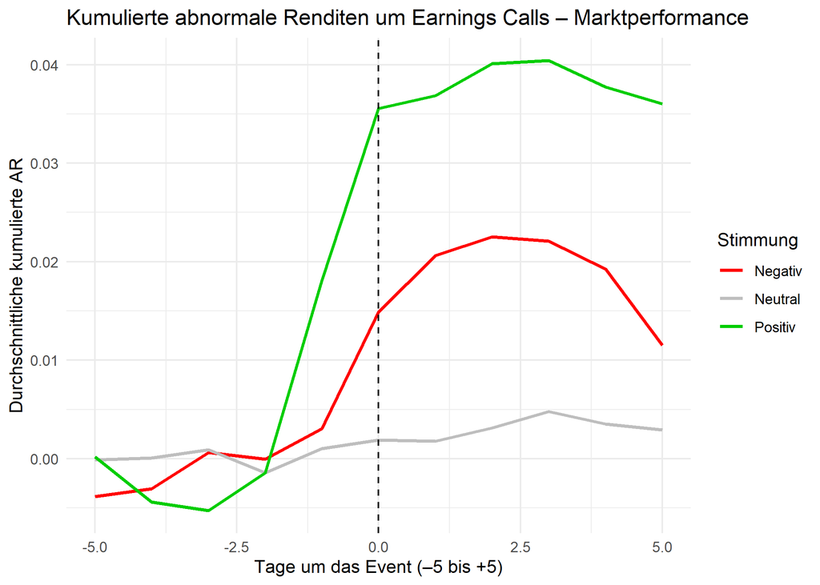

*Beschreibung und Interpretation der Grafiken*

Beide Grafiken zeigen die durchschnittlichen kumulierten abnormalen Renditen (AR) in Tagen um ein Ereignis (Earnings Call), von −5 Tagen vor bis +5 Tagen nach dem Event. Die vertikale gestrichelte Linie bei Tag 0 markiert den Zeitpunkt des Earnings Calls. Die Renditen sind nach der Stimmung der Earnings Calls (Negativ, Neutral, Positiv) farblich gekennzeichnet.

*Grafik 1: Kumulierte abnormale Renditen um Earnings Calls – Unternehmensperformance*

Rote Linie (Negativ): Unternehmen mit negativer Stimmung im Earnings Call zeigen vor dem Event bereits leicht negative, aber stabile kumulierte abnormale Renditen. Ab Tag −1 bis 0 steigt die rote Linie steil an und überschreitet die Nulllinie. Nach dem Event (ab Tag 0) setzt sich dieser Anstieg fort und erreicht seinen Höhepunkt bei ca. 0.06 an Tag 2.5, bevor er leicht fällt und am Ende des Zeitraums erneut ansteigt. Dies ist kontraintuitiv, da eine negative Stimmung typischerweise mit negativen Renditen assoziiert wird. Möglicherweise wird die „negative Stimmung“ nicht exakt im Sinne der Marktteilnehmer erfasst oder es handelt sich um ein Phänomen, bei dem negative Nachrichten bereits eingepreist sind und der Call eine Erholung oder geringere Negativität als erwartet signalisiert, was zu einer “Short Squeeze” oder einer Korrektur führt. Eine andere Erklärung könnte sein, dass Unternehmen mit bereits schlechter Performance bei einer negativen Stimmung sich überdurchschnittlich stark erholen oder positive Aspekte im Call doch überwiegen, die nicht in die Stimmungserkennung einfließen.

Graue Linie (Neutral): Unternehmen mit neutraler Stimmung weisen vor dem Event kumulierte abnormale Renditen nahe Null auf und bleiben auch nach dem Event weitestgehend in diesem Bereich, mit einer leichten Tendenz zu leicht positiven Renditen. Dies ist erwartungskonform, da neutrale Nachrichten keine signifikanten Reaktionen hervorrufen sollten.

Grüne Linie (Positiv): Unternehmen mit positiver Stimmung zeigen vor dem Event leicht positive bis neutrale kumulierte abnormale Renditen. Nach dem Event steigen die kumulierten abnormalen Renditen moderat an und erreichen einen Spitzenwert von knapp über 0.01 an Tag 2.5, bevor sie leicht absinken und dann wieder auf diesem Niveau verbleiben. Dies ist erwartungskonform und deutet darauf hin, dass positive Nachrichten zu einem Anstieg der Aktienkurse führen. Der Anstieg ist jedoch deutlich geringer als der Anstieg bei negativer Stimmung.

*Grafik 2: Kumulierte abnormale Renditen um Earnings Calls – Marktperformance*

Rote Linie (Negativ): Unternehmen mit negativer Stimmung zeigen vor dem Event leicht negative abnormale Renditen. Ähnlich wie in Grafik 1, kommt es zu einem steilen Anstieg der kumulierten abnormalen Renditen um Tag 0, die bis Tag 2.5 auf über 0.02 ansteigen und dann bis Tag 5 wieder auf ca. 0.01 fallen. Auch hier ist der anfängliche Anstieg bei negativer Stimmung schwer zu interpretieren und könnte auf die oben genannten Erklärungen oder eine spezifische Marktinterpretation hinweisen.

Graue Linie (Neutral): Ähnlich wie in Grafik 1, verbleiben die kumulierten abnormalen Renditen für neutrale Stimmung weitgehend um die Nulllinie, mit einer leichten positiven Tendenz nach dem Event.

Grüne Linie (Positiv): Unternehmen mit positiver Stimmung weisen vor dem Event leicht positive oder leicht negative abnormale Renditen auf. Der signifikanteste Anstieg der kumulierten abnormalen Renditen findet bei Tag 0 statt, wo die grüne Linie von knapp unter Null auf über 0.03 springt. Sie erreicht ihren Höhepunkt bei Tag 2.5 bei über 0.04 und fällt dann leicht bis Tag 5. Dies deutet auf eine starke positive Marktreaktion auf positive Nachrichten hin.

*Zusammenfassende Interpretation beider Grafiken:*

Die Ergebnisse für neutrale und positive Stimmungen sind weitgehend erwartungskonform. Neutrale Nachrichten führen zu kaum einer Reaktion, während positive Nachrichten zu positiven abnormalen Renditen führen.

Die auffälligste und kontraintuitivste Beobachtung ist das Verhalten der roten Linie (negative Stimmung) in beiden Grafiken. Ein deutlicher Anstieg der kumulierten abnormalen Renditen nach Earnings Calls mit negativer Stimmung ist unerwartet. Mögliche Erklärungen könnten sein:

Informationslecks oder Vorab-Reaktionen: Die negativen Informationen könnten bereits vor dem Call eingepreist gewesen sein, und der Call selbst liefert vielleicht weniger schlechte Nachrichten als befürchtet oder enthält Hinweise auf zukünftige Verbesserungen.

“Buy the Rumor, Sell the News” umgekehrt: Möglicherweise gab es im Vorfeld eine starke Short-Positionierung, die nach dem Call aufgelöst wurde, sobald die befürchteten Katastrophen nicht eintraten oder sogar eine relative Erleichterung eintrat.

Definition der “Stimmung”: Die Methode zur Bestimmung der “negativen Stimmung” könnte Aspekte übersehen, die vom Markt als weniger negativ oder sogar als potenziell positiv interpretiert werden. Beispielsweise könnte eine aggressive Restrukturierung, die kurzfristig negativ ist, langfristig als positiv wahrgenommen werden.

Datenartefakte oder spezifische Stichproben: Es könnte sich um ein spezifisches Merkmal der verwendeten Datenstichprobe handeln.

Potenzielle Probleme, wenn in der Schätzperiode vor dem Event ein weiterer Earnings-Conference Call enthalten ist:

Ja, es könnte zu erheblichen Problemen führen, wenn in der Schätzperiode (d.h. der Periode, in der die normalen Renditen geschätzt werden, um die abnormalen Renditen zu berechnen) vor dem aktuellen Earnings Call ein weiterer Earnings-Conference Call enthalten ist.

Warum dies ein Problem sein könnte:

Verletzung der Normalität der Renditen: Die Berechnung abnormaler Renditen basiert auf der Annahme, dass die Renditen während der Schätzperiode “normal” oder “erwartet” sind und nicht durch spezifische, unternehmensbezogene Nachrichtenereignisse beeinflusst werden. Ein Earnings Call ist jedoch ein signifikantes Nachrichtenereignis, das die Aktienkurse stark beeinflusst und somit die “Normalität” der Renditen in der Schätzperiode stören würde.

Verzerrung der Erwartungswerte: Wenn ein früherer Earnings Call in der Schätzperiode liegt, würden die in dieser Periode beobachteten Renditen bereits die Reaktion auf die Informationen dieses früheren Calls widerspiegeln. Dies würde dazu führen, dass die geschätzten normalen Renditen für die Schätzperiode verzerrt sind. Wenn diese verzerrten normalen Renditen dann verwendet werden, um die abnormalen Renditen für den aktuellen Earnings Call zu berechnen, wären auch diese abnormalen Renditen fehlerhaft. Man würde möglicherweise Effekte des früheren Calls fälschlicherweise dem aktuellen Call zuschreiben.

Nicht-Unabhängigkeit der Ereignisse: Ereignisstudien setzen voraus, dass die untersuchten Ereignisse voneinander unabhängig sind und keine gegenseitige Beeinflussung der Renditen in der Schätzperiode stattfindet. Wenn ein zweiter Earnings Call in der Schätzperiode liegt, sind die Ereignisse nicht mehr unabhängig, und die gemessenen abnormalen Renditen für das Hauptereignis könnten durch die Reaktion auf das frühere Ereignis kontaminiert sein.

Überschätzung oder Unterschätzung der echten Abnormalität: Angenommen, der frühere Call war sehr positiv. Dann würden die geschätzten normalen Renditen in der Schätzperiode höher ausfallen als sie tatsächlich wären, wenn kein Call stattgefunden hätte. Wenn dann der aktuelle Call ebenfalls positive Nachrichten bringt, könnten die daraus resultierenden abnormalen Renditen unterschätzt werden, weil der “Basiseffekt” bereits durch den früheren Call erhöht wurde. Umgekehrt könnten bei einem negativen früheren Call und einem negativen aktuellen Call die abnormalen Renditen überschätzt werden.

Warum dies möglicherweise kein Problem wäre (oder weniger problematisch):

In einigen spezialisierten Studienansätzen könnte dies bewusst zugelassen werden, wenn man beispielsweise die kumulativen Effekte über längere Zeiträume oder die Interaktion von Nachrichtenereignissen untersuchen möchte. Dies erfordert jedoch fortgeschrittenere Modellierungen und ist nicht die Standardvorgehensweise in einer klassischen Ereignisstudie. Für die in den Grafiken dargestellte Standard-Ereignisstudie, die die kurzfristige Marktreaktion auf ein einzelnes, spezifisches Ereignis isolieren möchte, wäre ein überlappender Earnings Call in der Schätzperiode problematisch.

*Fazit:*

Für eine korrekte und unverzerrte Messung der abnormalen Renditen rund um einen Earnings Call ist es von entscheidender Bedeutung, dass die Schätzperiode für die normalen Renditen frei von anderen signifikanten unternehmensspezifischen Nachrichtenereignissen wie weiteren Earnings Calls ist. Andernfalls würden die Ergebnisse die tatsächliche Marktreaktion auf das primäre Ereignis nicht akkurat widerspiegeln. Es ist üblich, Schätzperioden zu wählen, die weit genug vom Ereignis entfernt sind und keine solchen Überlappungen aufweisen.

20. Lesen Sie das Kapitel [“Fixed Effects” in Huntington-Klein (2021)](https://theeffectbook.net/ch-FixedEffects.html#how-does-it-work), speziell Kapitel 16.1
21. Regressieren Sie die `cmar_101` auf die Variablen *negativ_firm* und *negativ_market* und kontrollieren Sie auf die Größe des jeweiligen Unternehmens, indem Sie die Variable *Total_Assets* in ihre Regression aufnehmen. Kontrollieren Sie weiterhin auf das Jahr in dem das Event stattgefunden hat. Fügen Sie weiterhin der Regression Firmen-Fixe Effekte hinzu.

Beschreiben und interpretieren Sie ihre Ergebnisse.

Gehen Sie zusätzlich auf die folgenden Frage ein:

- Was sind Firmen-Fixe Effekte und warum könnten diese für ihre Regression sinnvoll sein?

*Hinweis:* Mit dem [Paket `fixest`](https://cran.r-project.org/web/packages/fixest/vignettes/fixest_walkthrough.html) und der Funktion feols() können Sie einfach ihren Regressionen fixe Effekte hinzufügen

|  | Negativ | Negativ mit Jahreskontrollen | Negativ mit Firmenfixen Effekten |
| --- | --- | --- | --- |
| (Intercept) | -0.022*** |  |  |
|  | (0.005) |  |  |
| negativ_firm | -0.083* | 0.032 | 0.066 |
|  | (0.034) | (0.045) | (0.041) |
| negativ_market | -0.014 | 0.008 | 0.004 |
|  | (0.012) | (0.019) | (0.017) |
| Total_Assets | 0.000** | 0.000 | 0.000 |
|  | (0.000) | (0.000) | (0.000) |
| Num.Obs. | 771 | 771 | 771 |
| AIC | -1105.4 | -1725.4 | -1706.2 |
| BIC | -1086.8 | -1683.6 | -1543.5 |
| Std.Errors | IID | by: year | by: year |

* p < 0.05, ** p < 0.01, *** p < 0.001

*Antwort:*

*Beschreibung und Interpretation der Regressionsergebnisse:*

Im Rahmen der Analyse wurde untersucht, wie sich negatives Sentiment in Earnings Calls auf die kumulierten risiko-adjustierten abnormalen Renditen (cmar_101) im Zeitraum von –1 bis +1 Handelstagen rund um das Event auswirkt. Es wurden drei Modelle geschätzt: ein Basismodell, ein Modell mit Jahreskontrollen sowie ein Modell mit Jahres- und Firmen-fixen Effekten.

*Einfluss negativer firmenspezifischer Aussagen:*

Im einfachen Modell ohne zusätzliche Kontrollen (Modell 1) zeigt sich ein signifikanter negativer Effekt der Variable negativ_firm auf die abnormalen Renditen. Der geschätzte Koeffizient beträgt –0.083 und ist auf dem 5 %-Niveau signifikant. Dies deutet darauf hin, dass Unternehmen, die sich negativ über ihre eigene Lage äußern, tendenziell eine geringere risiko-adjustierte Rendite im Umfeld des Earnings Calls erfahren.

In den Modellen mit Jahreskontrollen (Modell 2) sowie mit zusätzlichen Firmen-fixen Effekten (Modell 3) verschwindet dieser Effekt jedoch. Der Koeffizient verändert sich in Richtung Null bzw. wird positiv, ist aber in keinem dieser Modelle signifikant. Dies legt nahe, dass der ursprünglich beobachtete negative Zusammenhang möglicherweise durch unternehmensspezifische oder zeitliche Faktoren verzerrt war.

*Einfluss negativer Marktaussagen:*

Für das Marktsentiment (negativ_market) zeigt sich in keinem der drei Modelle ein signifikanter Effekt auf die abnormalen Renditen. Das deutet darauf hin, dass negative Aussagen über den Markt allgemein keinen direkten Einfluss auf die Aktienkursreaktion des berichtenden Unternehmens im Earnings Call haben.

*Einfluss der Unternehmensgröße:*

Die Unternehmensgröße, gemessen an den Total_Assets, zeigt im Basismodell einen kleinen, aber signifikanten positiven Zusammenhang mit der Rendite. In den Modellen mit Jahres- und Firmenkontrollen ist dieser Effekt jedoch nicht mehr signifikant, was darauf hinweist, dass der Zusammenhang möglicherweise nicht robust gegenüber strukturellen Unterschieden ist.

*Was sind Firmen-fixe Effekte und warum sind sie wichtig?:*

Firmen-fixe Effekte sind Kontrollgrößen, die es ermöglichen, unbeobachtete, zeitlich konstante Eigenschaften einzelner Unternehmen aus dem Modell herauszufiltern. Dazu gehören beispielsweise Unterschiede im Geschäftsmodell, in der Kommunikationsstrategie oder der generellen Marktstellung eines Unternehmens. Solche Unterschiede könnten dazu führen, dass bestimmte Firmen unabhängig vom Sentiment systematisch höhere oder niedrigere Renditen aufweisen. Die Aufnahme von Firmen-fixen Effekten verhindert somit, dass diese unbeobachteten Faktoren die Schätzung verzerren. In Modell 3, das diese Effekte berücksichtigt, verschwindet der ursprünglich signifikante Zusammenhang zwischen negativem Firmensentiment und abnormaler Rendite. Das deutet darauf hin, dass der Effekt im einfachen Modell durch strukturelle Unterschiede zwischen den Firmen getrieben war und nicht direkt auf das Sentiment selbst zurückzuführen ist.

*Fazit:*

Die Ergebnisse zeigen, dass sich die Aussagekraft negativer firmenspezifischer Stimmung in Earnings Calls deutlich verändert, sobald man strukturelle Unterschiede zwischen den Unternehmen und Zeittrends berücksichtigt. Ohne geeignete Kontrollen erscheint der Effekt zunächst negativ und signifikant – bei genauerer Betrachtung jedoch verliert er an Bedeutung. Dies unterstreicht die Notwendigkeit, Jahres- und Firmen-Fixe Effekte in Event-Studien zu berücksichtigen, um Kausalzusammenhänge korrekt zu identifizieren.

# Literatur

- Kapitel Event Studies im Buch [The Effect Book: Event Studies](https://theeffectbook.net/ch-EventStudies.html)
- Kapitel Fixe Effekte im Buch [The Effect Book: Event Studies](https://theeffectbook.net/ch-FixedEffects.html)
- [Paket `fixest`](https://cran.r-project.org/web/packages/fixest/vignettes/fixest_walkthrough.html)

# Anhang

## Prompt Arten

Prompt-Arten unterscheiden sich in der Anzahl der Beispiele, die Sie dem KI-Modell geben:

**Zero-Shot Prompt**

- Keine Beispiele gegeben
- Nur die Aufgabe wird beschrieben
- Beispiel: “Übersetze ins Englische: Guten Morgen”

**One-Shot Prompt**

- Ein einziges Beispiel wird gezeigt
- Das Modell lernt aus diesem einen Beispiel
- Beispiel: “Übersetze ins Englische:

Guten Tag → Good day Guten Morgen → ?”

**Few-Shot Prompt**

- Mehrere Beispiele werden gegeben (typisch 2-5)
- Das Modell kann aus mehreren Mustern lernen
- Beispiel: “Übersetze ins Englische:

Guten Tag → Good day Auf Wiedersehen → Goodbye Danke → Thank you Guten Morgen → ?”